# AAProject_Group26

We wanted to investigate if richer people donated more than other donors. For that, we plotted `MEDIAN_HOME_VALUE` and `MEDIAN_HOUSEHOLD_INCOME`, 2 economic features, and colored the dots according to `TARGET_D`, the donation amount in the last charity drive, and `FILE_CARD_GIFT`, the average lifetime donation amount. We would expect that richer people, the dots higher ups in the plot, would have donated the highest amounts.

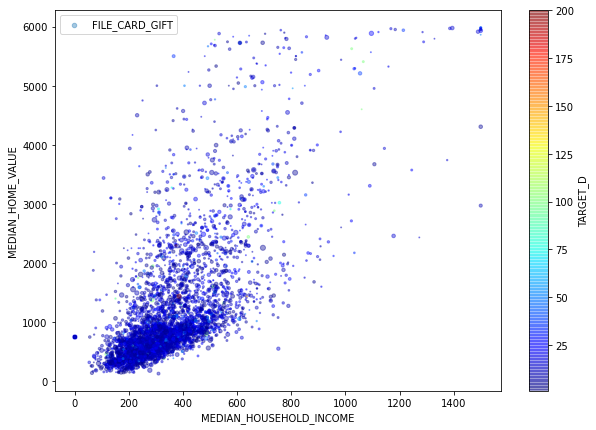

```python
cmap = plt.cm.get_cmap('Reds')
activedonors.plot(kind='scatter',x='MEDIAN_HOUSEHOLD_INCOME', y='MEDIAN_HOME_VALUE', alpha=0.4,
           figsize=(10,7), s=activedonors['FILE_CARD_GIFT'], label='FILE_CARD_GIFT',
           c='TARGET_D',  colorbar=True, colormap='jet',
           sharex=False)
plt.show();
```

It seems that richer people do NOT, in fact, donate more than other people. The majority of donors have low values of both economic features and donate as much as the richest donors. We can easily identify richer donors who have donated less in the last charity drive and less overall than the majority, contrary to what we expected to find.

Next, we intended to evaluate the influence of both active military and veterans in the neighborhood where a person lives in the donation amount.

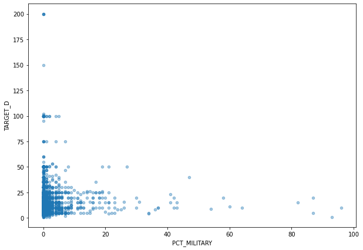

```python
cmap = plt.cm.get_cmap('Reds')
activedonors.plot(kind='scatter',y='TARGET_D', x='PCT_MILITARY', alpha=0.4,
           figsize=(10,7),
           sharex=False)
plt.show();
```

Active military doesn't seem to influence the donation amount, with the majority of donors living in neighborhoods with low or no percentage of military. Neighborhoods with high percentage of military show similar donation amounts to those with low percentage.

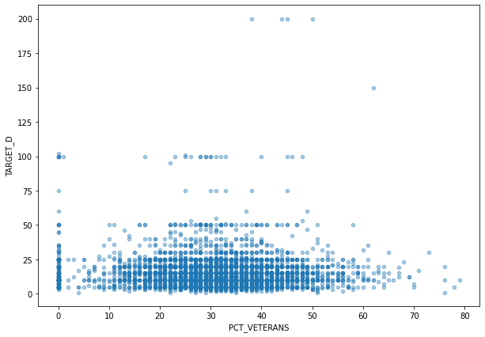

```python
cmap = plt.cm.get_cmap('Reds')
activedonors.plot(kind='scatter',y='TARGET_D', x='PCT_VETERANS', alpha=0.4,
           figsize=(10,7),
           sharex=False)
plt.show();
```

We see that high percentage of veterans living in a neighborhood leads to a higher chance of donation, with the majority of donors living in neighborhoods with 20 to 40% of veterans. However, higher percentages don't lead to higher donation amounts, as we can see that `TARGET_D` is very similar throughout the plot (ranging from 5 to 25$).

# Task 1 (Supervised Learning) - Predicting Donation and Donation Type

In this task you should target 3 classification tasks:

1. **Predicting Donation (binary classification task)**;
2. **Predicting Donation TYPE (multiclass classification)**;
3. **Train specialized models for SES (socioeconomic classification)**.

**You should:**

- Choose **one classifier in each category**: Tree models, Rule models, Linear models, Distance-based models, and Probabilistic models.
- Use cross-validation to evaluate the results.
- Present and discuss the results for different evaluation measures, present confusion matrices. Remember that not only overall results are important. Check what happens when learning to predict each class.
- Describe the parameters used for each classifier and how their choice impacted or not the results.
- Choose the best classifier and fundament you choice.
- **Discuss critically your choices and the results!**

# Task 1.1) Predicting Donation (binary classification task) - TARGET_B

We had already previously observed the feature TARGET_B, we were dealing with an imbalanced data set. When learning from data sets that contain very few instances of the minority class, in many cases the algorithm tends to favor the majority class while the minority class usually represents the most important concept to be learned (individuals who donated).

```python
donors.head(2)
```

|  | TARGET_B | TARGET_D | DONOR_AGE | IN_HOUSE | URBANICITY | SES | HOME_OWNER | DONOR_GENDER | PUBLISHED_PHONE | MOR_HIT_RATE | MEDIAN_HOME_VALUE | MEDIAN_HOUSEHOLD_INCOME | PCT_OWNER_OCCUPIED | PCT_MILITARY | PCT_VETERANS | RECENCY_STATUS_96NK | FREQUENCY_STATUS_97NK | RECENT_RESPONSE_PROP | RECENT_AVG_GIFT_AMT | RECENT_CARD_RESPONSE_PROP | RECENT_AVG_CARD_GIFT_AMT | RECENT_CARD_RESPONSE_COUNT | MONTHS_SINCE_LAST_PROM_RESP | LIFETIME_AVG_GIFT_AMT | LAST_GIFT_AMT | CARD_PROM_12 | MONTHS_SINCE_LAST_GIFT | MONTHS_SINCE_FIRST_GIFT | FILE_CARD_GIFT | … |
| --- | --- | --- | --- | --- | --- | --- | --- | --- | --- | --- | --- | --- | --- | --- | --- | --- | --- | --- | --- | --- | --- | --- | --- | --- | --- | --- | --- | --- | --- | --- |
| 0 | 0 | 0.0 | 87.0 | 0 | S | 2.0 | H | M | 0 | 0 | 554.0 | 294 | 76 | 0 | 0 | A | 1 | 0.067 | 15.0 | 0.00 | 0.0 | 0 | 26.0 | 8.49 | 15.0 | 5 | 26 | 92 | 7 | … |
| 1 | 1 | 10.0 | 79.0 | 0 | R | 2.0 | H | M | 0 | 0 | 334.0 | 212 | 72 | 0 | 41 | S | 2 | 0.235 | 15.0 | 0.25 | 15.0 | 2 | 11.0 | 14.72 | 17.0 | 7 | 7 | 122 | 12 | … |

```python
encoder = OneHotEncoder(handle_unknown='ignore',sparse=False)
cat_features_final = encoder.fit_transform(donors[donors_cat])
column_name = encoder.get_feature_names(donors_cat)
one_hot_encoded_cat =  pd.DataFrame(cat_features_final, columns= column_name)
print(one_hot_encoded_cat.shape)
```

```
(19372, 179)
```

```python
# num features - scalling
numericalfeatures = ['CARD_PROM_12','DONOR_AGE','FILE_CARD_GIFT',
                    'LAST_GIFT_AMT','LIFETIME_AVG_GIFT_AMT','MEDIAN_HOME_VALUE',
                    'MEDIAN_HOUSEHOLD_INCOME','MONTHS_SINCE_FIRST_GIFT',
                    'MOR_HIT_RATE', 'RECENT_AVG_CARD_GIFT_AMT','RECENT_AVG_GIFT_AMT',
                    'RECENT_CARD_RESPONSE_COUNT','RECENT_CARD_RESPONSE_PROP','RECENT_RESPONSE_PROP']
```

- **Feature Scaling** : As we have vastly different ranges for the numerical data, it is important to scale every value to the same range (0 for the minimum, 1 for the maximum).

```python
donors_num = donors[['CARD_PROM_12','DONOR_AGE','FILE_CARD_GIFT',
                    'LAST_GIFT_AMT','LIFETIME_AVG_GIFT_AMT','MEDIAN_HOME_VALUE',
                    'MEDIAN_HOUSEHOLD_INCOME','MONTHS_SINCE_FIRST_GIFT',
                    'MOR_HIT_RATE', 'RECENT_AVG_CARD_GIFT_AMT','RECENT_AVG_GIFT_AMT',
                    'RECENT_CARD_RESPONSE_COUNT','RECENT_CARD_RESPONSE_PROP','RECENT_RESPONSE_PROP']]
```

```python
scaler = MinMaxScaler()
scaled = scaler.fit_transform(donors_num)

# creating a scaled dataframe
donors_num_scaled = pd.DataFrame(scaled)
donors_num_scaled.columns = donors_num.columns
```

```python
donors_num_scaled.shape
```

```
(19372, 14)
```

```python
donors_final = pd.concat([donors_num_scaled, one_hot_encoded_cat], axis=1)
```

```python
donors_final.head(2)
```

|  | CARD_PROM_12 | DONOR_AGE | FILE_CARD_GIFT | LAST_GIFT_AMT | LIFETIME_AVG_GIFT_AMT | MEDIAN_HOME_VALUE | MEDIAN_HOUSEHOLD_INCOME | MONTHS_SINCE_FIRST_GIFT | MOR_HIT_RATE | RECENT_AVG_CARD_GIFT_AMT | RECENT_AVG_GIFT_AMT | RECENT_CARD_RESPONSE_COUNT | RECENT_CARD_RESPONSE_PROP | RECENT_RESPONSE_PROP | DONOR_GENDER_F | DONOR_GENDER_M | DONOR_GENDER_U | RECENCY_STATUS_96NK_A | RECENCY_STATUS_96NK_E | RECENCY_STATUS_96NK_F | RECENCY_STATUS_96NK_L | RECENCY_STATUS_96NK_N | RECENCY_STATUS_96NK_S | HOME_OWNER_H | HOME_OWNER_U | IN_HOUSE_0 | IN_HOUSE_1 | PCT_MILITARY_0 | PCT_MILITARY_1 | … |
| --- | --- | --- | --- | --- | --- | --- | --- | --- | --- | --- | --- | --- | --- | --- | --- | --- | --- | --- | --- | --- | --- | --- | --- | --- | --- | --- | --- | --- | --- | --- |
| 0 | 0.294118 | 1.000000 | 0.170732 | 0.033333 | 0.015892 | 0.080844 | 0.196000 | 0.314286 | 0.0 | 0.00 | 0.057692 | 0.000000 | 0.00 | 0.067 | 0.0 | 1.0 | 0.0 | 1.0 | 0.0 | 0.0 | 0.0 | 0.0 | 0.0 | 1.0 | 0.0 | 1.0 | 0.0 | 1.0 | 0.0 | … |
| 1 | 0.411765 | 0.905882 | 0.292683 | 0.037778 | 0.029779 | 0.043713 | 0.141333 | 0.436735 | 0.0 | 0.05 | 0.057692 | 0.222222 | 0.25 | 0.235 | 0.0 | 1.0 | 0.0 | 0.0 | 0.0 | 0.0 | 0.0 | 0.0 | 1.0 | 1.0 | 0.0 | 1.0 | 0.0 | 1.0 | 0.0 | … |

```python
donors_final.shape
```

```
(19372, 193)
```

```python
donors_final = donors_final.sort_index(ascending=True)
```

```python
y_TARGET_B = donors.TARGET_B
y_TARGET_B
```

```
0        0
1        1
2        0
3        0
4        0
        ..
19367    0
19368    0
19369    0
19370    0
19371    1
Name: TARGET_B, Length: 19372, dtype: int64
```

```python
print('Shape of X: {}'.format(donors_final.shape))
print('Shape of y: {}'.format(y_TARGET_B.shape))
```

```
Shape of X: (19372, 193)
Shape of y: (19372,)
```

```python
df_final = pd.concat([donors_final, y_TARGET_B], axis=1)
```

```python
df_final.head(3)
```

|  | CARD_PROM_12 | DONOR_AGE | FILE_CARD_GIFT | LAST_GIFT_AMT | LIFETIME_AVG_GIFT_AMT | MEDIAN_HOME_VALUE | MEDIAN_HOUSEHOLD_INCOME | MONTHS_SINCE_FIRST_GIFT | MOR_HIT_RATE | RECENT_AVG_CARD_GIFT_AMT | RECENT_AVG_GIFT_AMT | RECENT_CARD_RESPONSE_COUNT | RECENT_CARD_RESPONSE_PROP | RECENT_RESPONSE_PROP | DONOR_GENDER_F | DONOR_GENDER_M | DONOR_GENDER_U | RECENCY_STATUS_96NK_A | RECENCY_STATUS_96NK_E | RECENCY_STATUS_96NK_F | RECENCY_STATUS_96NK_L | RECENCY_STATUS_96NK_N | RECENCY_STATUS_96NK_S | HOME_OWNER_H | HOME_OWNER_U | IN_HOUSE_0 | IN_HOUSE_1 | PCT_MILITARY_0 | PCT_MILITARY_1 | … |
| --- | --- | --- | --- | --- | --- | --- | --- | --- | --- | --- | --- | --- | --- | --- | --- | --- | --- | --- | --- | --- | --- | --- | --- | --- | --- | --- | --- | --- | --- | --- |
| 0 | 0.294118 | 1.000000 | 0.170732 | 0.033333 | 0.015892 | 0.080844 | 0.196000 | 0.314286 | 0.0 | 0.000000 | 0.057692 | 0.000000 | 0.000 | 0.067 | 0.0 | 1.0 | 0.0 | 1.0 | 0.0 | 0.0 | 0.0 | 0.0 | 0.0 | 1.0 | 0.0 | 1.0 | 0.0 | 1.0 | 0.0 | … |
| 1 | 0.411765 | 0.905882 | 0.292683 | 0.037778 | 0.029779 | 0.043713 | 0.141333 | 0.436735 | 0.0 | 0.050000 | 0.057692 | 0.222222 | 0.250 | 0.235 | 0.0 | 1.0 | 0.0 | 0.0 | 0.0 | 0.0 | 0.0 | 0.0 | 1.0 | 1.0 | 0.0 | 1.0 | 0.0 | 1.0 | 0.0 | … |
| 2 | 0.647059 | 0.858824 | 0.390244 | 0.042222 | 0.034304 | 0.390380 | 0.270000 | 0.367347 | 0.0 | 0.075567 | 0.083346 | 0.666667 | 0.545 | 0.409 | 1.0 | 0.0 | 0.0 | 0.0 | 0.0 | 0.0 | 0.0 | 0.0 | 1.0 | 1.0 | 0.0 | 1.0 | 0.0 | 1.0 | 0.0 | … |

```python
duplicateRowsDF = df_final[df_final.duplicated()] #checking
duplicateRowsDF
```

|  | CARD_PROM_12 | DONOR_AGE | FILE_CARD_GIFT | LAST_GIFT_AMT | LIFETIME_AVG_GIFT_AMT | MEDIAN_HOME_VALUE | MEDIAN_HOUSEHOLD_INCOME | MONTHS_SINCE_FIRST_GIFT | MOR_HIT_RATE | RECENT_AVG_CARD_GIFT_AMT | RECENT_AVG_GIFT_AMT | RECENT_CARD_RESPONSE_COUNT | RECENT_CARD_RESPONSE_PROP | RECENT_RESPONSE_PROP | DONOR_GENDER_F | DONOR_GENDER_M | DONOR_GENDER_U | RECENCY_STATUS_96NK_A | RECENCY_STATUS_96NK_E | RECENCY_STATUS_96NK_F | RECENCY_STATUS_96NK_L | RECENCY_STATUS_96NK_N | RECENCY_STATUS_96NK_S | HOME_OWNER_H | HOME_OWNER_U | IN_HOUSE_0 | IN_HOUSE_1 | PCT_MILITARY_0 | PCT_MILITARY_1 | … |
| --- | --- | --- | --- | --- | --- | --- | --- | --- | --- | --- | --- | --- | --- | --- | --- | --- | --- | --- | --- | --- | --- | --- | --- | --- | --- | --- | --- | --- | --- | --- |

```python
def perf_metrics(grid_search_model, y_pred_model, X_test, y_test):
    print(grid_search_model.estimator, "Results: ")
    confusion_matrix_test = confusion_matrix(y_pred_model, y_test)
    print("Confusion Matrix Test Set")
    TP = confusion_matrix_test[1, 1]
    TN = confusion_matrix_test[0, 0]
    FP = confusion_matrix_test[0, 1]
    FN = confusion_matrix_test[1, 0]
    print(confusion_matrix_test)
    print("In the test set:")
    print(TN,"individuals were correctly classified as 'not-donors' (TN).")
    print(TP,"individuals were correctly classified as 'donors' (TP).")
    print(FP,"individuals were wrongly classified as 'donors' (FP).")
    print(FN,"individuals were wrongly classified as 'not-donors' (FN).")
    accuracy_test = accuracy_score(y_test, y_pred_model)
    print("The model predicted {}% of the individuals correctly in the test set.".format(np.round(accuracy_test*100,2)))
    precision_test = precision_score(y_test, y_pred_model)
    print("The model predicted correctly that an individual will donate {}% of the times in the test set.".format(np.round(precision_test*100,4)))
    recall_test = recall_score(y_test,y_pred_model)
    print("The model predicted the donation of {}% of the passengers who actually donated in the test set.".format(np.round(recall_test*100,4)))
    f1_test = f1_score(y_test,y_pred_model) #F1 score can be interpreted as a weighted average of the precision and recall
    #best value F1=1, worst value F1=0
    print("The F1 score is",round(f1_test,4))

    print ("Area under the ROC = ", np.round(roc_auc_score(y_test, grid_search_model.predict_proba(X_test)[:,1]),2))

    y_predict_proba = grid_search_model.predict_proba(X_test)[:,1]
    fpr, tpr, thresholds = roc_curve(y_test, y_predict_proba)
    roc_auc = auc(fpr, tpr)
    roc_auc_score(y_test, y_predict_proba) #AUC will remain the same regardless of varying threshold

    plt.figure()
    lw = 2
    plt.plot(fpr, tpr, color='darkorange',
             lw=lw, label='ROC curve (area = %0.2f)' % roc_auc)
    plt.plot([0, 1], [0, 1], color='navy', lw=lw, linestyle='--')
    plt.xlim([0.0, 1.0])
    plt.ylim([0.0, 1.05])
    plt.xlabel('False Positive Rate')
    plt.ylabel('True Positive Rate')
    plt.title('Receiver operating characteristic')
    plt.legend(loc="lower right")
    plt.show()
```

```python
def best_par(grid_search_model):
    print ("Best Score (Area under the ROC curve)=", np.round(grid_search_model.best_score_,2))
    print ("Best Parameters", grid_search_model.best_params_)
    print ("Best Estimator",grid_search_model.best_estimator_)
```

```python
df_final.shape
```

```
(19372, 194)
```

```python
X= df_final.drop(['TARGET_B'],axis=1)
y_TARGET_B = df_final.TARGET_B
```

```python
print(X.shape,y_TARGET_B.shape)
```

```
(19372, 193) (19372,)
```

```python
X_train, X_test, y_train, y_test = train_test_split(df_final.drop(['TARGET_B'],axis=1), df_final.TARGET_B, test_size=0.2, random_state=0)
```

```python
print(X_train.shape, X_test.shape, y_train.shape, y_test.shape)
```

```
(15497, 193) (3875, 193) (15497,) (3875,)
```

- We will use grid search with cross-validation (with the help of the GridSearchCV from scikit-learn) to find good hyperparameter values for our models.
- We will train our model on the full training set using these hyperparameters, and measure then model’s performance on the test set.

**1.1.a) Linear Model - Logistic Regression**

```python
logit_clf = LogisticRegression(random_state=42, solver='liblinear').fit(X, y_TARGET_B)
```

```python
y_predict_logit_clf = cross_val_predict(logit_clf, X, y_TARGET_B, cv=10, n_jobs=-1)
```

```python
confusion_matrix_test = confusion_matrix(y_predict_logit_clf, y_TARGET_B)
print("Confusion Matrix Test Set")
TP = confusion_matrix_test[1, 1]
TN = confusion_matrix_test[0, 0]
FP = confusion_matrix_test[0, 1]
FN = confusion_matrix_test[1, 0]
print(confusion_matrix_test)
print("In the test set:")
print(TN,"individuals were correctly classified as 'not-donors' (TN).")
print(TP,"individuals were correctly classified as 'donors' (TP).")
print(FP,"individuals were wrongly classified as 'donors' (FP).")
print(FN,"individuals were wrongly classified as 'not-donors' (FN).")
```

```
Confusion Matrix Test Set
[[14389  4756]
 [  140    87]]
In the test set:
14389 individuals were correctly classified as 'not-donors' (TN).
87 individuals were correctly classified as 'donors' (TP).
4756 individuals were wrongly classified as 'donors' (FP).
140 individuals were wrongly classified as 'not-donors' (FN).
```

```python
accuracy_test = accuracy_score(y_TARGET_B, y_predict_logit_clf)
print("The model predicted {}% of the individuals correctly in the test set.".format(np.round(accuracy_test*100,2)))
precision_test = precision_score(y_TARGET_B, y_predict_logit_clf)
print("The model predicted correctly that an individual will donate {}% of the times in the test set.".format(np.round(precision_test*100,4)))
recall_test = recall_score(y_TARGET_B,y_predict_logit_clf)
print("The model predicted the donation of {}% of the passengers who actually donated in the test set.".format(np.round(recall_test*100,4)))
f1_test = f1_score(y_TARGET_B,y_predict_logit_clf)
print("The F1 score of the model is",round(f1_test,4))
```

```
The model predicted 74.73% of the individuals correctly in the test set.
The model predicted correctly that an individual will donate 38.326% of the times in the test set.
The model predicted the donation of 1.7964% of the passengers who actually donated in the test set.
The F1 score of the model is 0.0343
```

```
ROC =  0.59
```

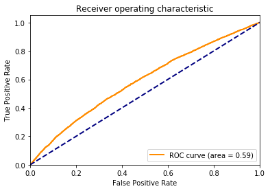

```python
y_predict_proba = cross_val_predict(logit_clf, X, y_TARGET_B, cv=10, method='predict_proba')[:, 1]
fpr, tpr, thresholds = roc_curve(y_TARGET_B, y_predict_proba)
roc_auc = auc(fpr, tpr)
print('ROC = ', np.round(roc_auc,2))
plt.figure()
lw = 2
plt.plot(fpr, tpr, color='darkorange',
         lw=lw, label='ROC curve (area = %0.2f)' % roc_auc)
plt.plot([0, 1], [0, 1], color='navy', lw=lw, linestyle='--')
plt.xlim([0.0, 1.0])
plt.ylim([0.0, 1.05])
plt.xlabel('False Positive Rate')
plt.ylabel('True Positive Rate')
plt.title('Receiver operating characteristic')
plt.legend(loc="lower right")
plt.show()
```

However if we want to increase the recall/sensitivy of our model, this may result in a decrease of the precision (depending on the threshold).

**1.1.b) Probabilistic Model - Naive Bayes**

```python
nb = GaussianNB()
nb_param_grid = { 'var_smoothing' : [0.1,0.2,0.3,0.4,0.5,0.6,0.7,0.8,0.9,1]}
nb_grid_search = GridSearchCV(nb,param_grid=nb_param_grid,cv=10, scoring='roc_auc', n_jobs=-1)
nb_grid_search.fit(X_train, y_train)
nb_pred=nb_grid_search.predict(X_test)
```

```python
best_par(nb_grid_search)
```

```
Best Score (Area under the ROC curve)= 0.59
Best Parameters {'var_smoothing': 0.6}
Best Estimator GaussianNB(var_smoothing=0.6)
```

```
GaussianNB() Results:
Confusion Matrix Test Set
[[2881  953]
 [  24   17]]
In the test set:
2881 individuals were correctly classified as 'not-donors' (TN).
17 individuals were correctly classified as 'donors' (TP).
953 individuals were wrongly classified as 'donors' (FP).
24 individuals were wrongly classified as 'not-donors' (FN).
The model predicted 74.79% of the individuals correctly in the test set.
The model predicted correctly that an individual will donate 41.4634% of the times in the test set.
The model predicted the donation of 1.7526% of the passengers who actually donated in the test set.
The F1 score is 0.0336
Area under the ROC =  0.59
```

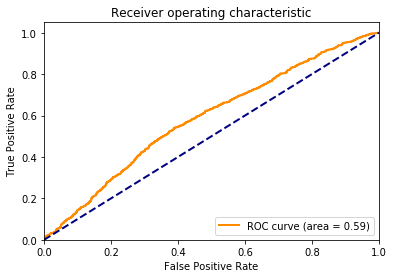

```python
perf_metrics(nb_grid_search, nb_pred, X_test, y_test)
```

**1.1.c) Tree Model - Decision Tree**

```python
dt = DecisionTreeClassifier()
param_grid = { 'max_depth' : list(range(1, 20)),
             'max_features':list(range(1,50,5)),
             'criterion':list(['gini','entropy'])}
grid_search_dt= GridSearchCV(dt,param_grid=param_grid,cv=10, scoring='roc_auc', n_jobs=1)
grid_search_dt.fit(X_train, y_train)
```

```
GridSearchCV(cv=10, estimator=DecisionTreeClassifier(), n_jobs=1,
             param_grid={'criterion': ['gini', 'entropy'],
                         'max_depth': [1, 2, 3, 4, 5, 6, 7, 8, 9, 10, 11, 12,
                                       13, 14, 15, 16, 17, 18, 19],
                         'max_features': [1, 6, 11, 16, 21, 26, 31, 36, 41,
                                          46]},
             scoring='roc_auc')
```

```python
best_par(grid_search_dt)
```

```
Best Score (Area under the ROC curve)= 0.6
Best Parameters {'criterion': 'entropy', 'max_depth': 6, 'max_features': 26}
Best Estimator DecisionTreeClassifier(criterion='entropy', max_depth=6, max_features=26)
```

```python
y_pred_dt = grid_search_dt.predict(X_test)
```

```
DecisionTreeClassifier() Results:
Confusion Matrix Test Set
[[2864  941]
 [  41   29]]
In the test set:
2864 individuals were correctly classified as 'not-donors' (TN).
29 individuals were correctly classified as 'donors' (TP).
941 individuals were wrongly classified as 'donors' (FP).
41 individuals were wrongly classified as 'not-donors' (FN).
The model predicted 74.66% of the individuals correctly in the test set.
The model predicted correctly that an individual will donate 41.4286% of the times in the test set.
The model predicted the donation of 2.9897% of the passengers who actually donated in the test set.
The F1 score is 0.0558
Area under the ROC =  0.58
```

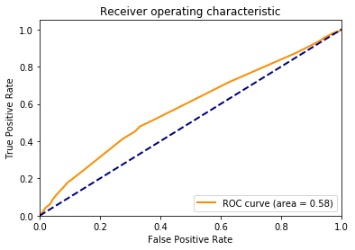

```python
perf_metrics(grid_search_dt, y_pred_dt, X_test, y_test)
```

**1.1.d) Distance based Model - KNN**

```python
knn = KNeighborsClassifier()
param_grid = { 'n_neighbors' : list(range(1, 20)) }

grid_search_knn = GridSearchCV(knn,param_grid=param_grid,cv=10, scoring='roc_auc', n_jobs=-1)
grid_search_knn.fit(X_train, y_train)
```

```
GridSearchCV(cv=10, estimator=KNeighborsClassifier(), n_jobs=-1,
             param_grid={'n_neighbors': [1, 2, 3, 4, 5, 6, 7, 8, 9, 10, 11, 12,
                                         13, 14, 15, 16, 17, 18, 19]},
             scoring='roc_auc')
```

```python
best_par(grid_search_knn)
```

```
Best Score (Area under the ROC curve)= 0.55
Best Parameters {'n_neighbors': 18}
Best Estimator KNeighborsClassifier(n_neighbors=18)
```

```python
y_pred_knn=grid_search_knn.predict(X_test)
```

```
KNeighborsClassifier() Results:
Confusion Matrix Test Set
[[2876  956]
 [  29   14]]
In the test set:
2876 individuals were correctly classified as 'not-donors' (TN).
14 individuals were correctly classified as 'donors' (TP).
956 individuals were wrongly classified as 'donors' (FP).
29 individuals were wrongly classified as 'not-donors' (FN).
The model predicted 74.58% of the individuals correctly in the test set.
The model predicted correctly that an individual will donate 32.5581% of the times in the test set.
The model predicted the donation of 1.4433% of the passengers who actually donated in the test set.
The F1 score is 0.0276
Area under the ROC =  0.53
```

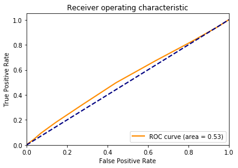

```python
perf_metrics(grid_search_knn, y_pred_knn, X_test, y_test)
```

**1.1.e) Rule model - Apriori model**

```python
donors_apriori = donors.copy()
```

```python
transform_cat = ['IN_HOUSE',
                'URBANICITY',
                'SES',
                'HOME_OWNER',
                'DONOR_GENDER',
                'PUBLISHED_PHONE',
                'MOR_HIT_RATE',
                'RECENCY_STATUS_96NK',
                'FREQUENCY_STATUS_97NK',
                'TARGET_B']
```

```python
donors_activeCat = donors_apriori[transform_cat].astype(str)
```

```python
for col in donors_apriori.columns:
    if col in transform_cat:
        donors[col] = donors[col].astype('category',copy=False)
```

[output not shown]

```python
TARGET_B_dict = {'1': "donor", '0': "not-donor"}
IN_HOUSE_dict = {'1': "inhouse", '0': "not-inhouse"}
URBANICITY_dict = {'C':'city','R':'rural','T':'town','S':'suburban'}
SES_dict = {'1.0':'SES1','2.0':'SES2','3.0':'SES3','4.0':'SES4'}
HOME_OWNER_dict = {'H':'homeowner','U':'unknown_homeowner'}
DONOR_GENDER_dict = {'M':'male','F':'female','U':'unknown_gender'}
PUBLISHED_PHONE_dict = {'0':'not_published','1':'published'}
MOR_HIT_RATE_dict = {'0':'other_non_donor','1':'published_phone'}
RECENCY_STATUS_96NK_dict = {'S':'star','A':'active','F':'first time','N':'new','E':'inactive','L':'lapsing'}
FREQUENCY_STATUS_97NK_dict = {'1.0':'1_don','2.0':'2_don','3.0':'3_don','4.0':'4_don'}
```

```python
donors_activeCat.replace({"TARGET_B": TARGET_B_dict}, inplace=True)
donors_activeCat.replace({"IN_HOUSE": IN_HOUSE_dict}, inplace=True)
donors_activeCat.replace({"URBANICITY": URBANICITY_dict}, inplace=True)
donors_activeCat.replace({"SES": SES_dict}, inplace=True)
donors_activeCat.replace({"HOME_OWNER": HOME_OWNER_dict}, inplace=True)
donors_activeCat.replace({"DONOR_GENDER": DONOR_GENDER_dict}, inplace=True)
donors_activeCat.replace({"PUBLISHED_PHONE": PUBLISHED_PHONE_dict}, inplace=True)
donors_activeCat.replace({"MOR_HIT_RATE": MOR_HIT_RATE_dict}, inplace=True)
donors_activeCat.replace({"RECENCY_STATUS_96NK": RECENCY_STATUS_96NK_dict}, inplace=True)
donors_activeCat.replace({"FREQUENCY_STATUS_97NK": FREQUENCY_STATUS_97NK_dict}, inplace=True)
```

```python
donors_activeCat.head(3)
```

|  | IN_HOUSE | URBANICITY | SES | HOME_OWNER | DONOR_GENDER | PUBLISHED_PHONE | MOR_HIT_RATE | RECENCY_STATUS_96NK | FREQUENCY_STATUS_97NK | TARGET_B |
| --- | --- | --- | --- | --- | --- | --- | --- | --- | --- | --- |
| 0 | not-inhouse | Suburban | SES2 | homeowner | male | not_published | other_non_donor | active | 1_don | not-donor |
| 1 | not-inhouse | rural | SES2 | homeowner | male | not_published | other_non_donor | star | 2_don | donor |
| 2 | not-inhouse | Suburban | SES1 | homeowner | female | not_published | other_non_donor | star | 3_don | not-donor |

```python
apriori_vals = donors_activeCat.values.tolist()
```

```python
#finding associations
te = TransactionEncoder()
te_ary = te.fit(apriori_vals).transform(apriori_vals)
binary_database = pd.DataFrame(te_ary, columns=te.columns_)
binary_database
```

|  | 1_don | 2_don | 3_don | 4_don | SES1 | SES2 | SES3 | SES4 | Suburban | U | active | city | donor | female | first time | homeowner | inactive | inhouse | lapsing | male | new | not-donor | not-inhouse | not_published | other_non_donor | published | published_phone | rural | star | … |
| --- | --- | --- | --- | --- | --- | --- | --- | --- | --- | --- | --- | --- | --- | --- | --- | --- | --- | --- | --- | --- | --- | --- | --- | --- | --- | --- | --- | --- | --- | --- |
| 0 | True | False | False | False | False | True | False | False | True | False | True | False | False | False | False | True | False | False | False | True | False | True | True | True | True | False | False | False | False | … |
| 1 | False | True | False | False | False | True | False | False | False | False | False | False | True | False | False | True | False | False | False | True | False | False | True | True | True | False | False | True | True | … |
| 2 | False | False | True | False | True | False | False | False | True | False | False | False | False | True | False | True | False | False | False | False | False | True | True | True | True | False | False | False | True | … |
| 3 | False | False | True | False | False | True | False | False | False | True | True | False | False | True | False | True | False | False | False | False | False | True | True | False | True | True | False | False | False | … |
| 4 | True | False | False | False | False | True | False | False | False | False | True | False | False | True | False | False | False | False | False | False | False | True | True | False | False | True | True | True | False | … |
| ... | ... | ... | ... | ... | ... | ... | ... | ... | ... | ... | ... | ... | ... | ... | ... | ... | ... | ... | ... | ... | ... | ... | ... | ... | ... | ... | ... | ... | ... | … |
| 19367 | False | True | False | False | True | False | False | False | False | True | True | False | False | True | False | True | False | True | False | False | False | True | False | False | False | True | True | False | False | … |
| 19368 | False | False | True | False | True | False | False | False | False | False | False | True | False | True | False | True | False | True | False | False | False | True | False | False | False | True | True | False | True | … |
| 19369 | True | False | False | False | True | False | False | False | True | False | False | False | False | False | False | False | False | True | False | True | True | True | False | False | True | True | False | False | False | … |
| 19370 | True | False | False | False | False | True | False | False | True | False | True | False | False | False | False | False | False | True | False | True | False | True | False | False | True | True | False | False | False | … |
| 19371 | True | False | False | False | False | True | False | False | True | False | False | False | True | False | False | False | False | False | False | True | True | False | True | False | False | True | True | False | False | … |

19372 rows × 31 columns

```python
#Identifying frequent itemsets using Apriori and computing itemsets with min_support = 50%
frequent_itemsets = apriori(binary_database, min_support=0.5, use_colnames=True)
frequent_itemsets
```

|  | support | itemsets |
| --- | --- | --- |
| 0 | 0.502684 | (SES2) |
| 1 | 0.615218 | (active) |
| 2 | 0.536909 | (female) |
| 3 | 0.547491 | (homeowner) |
| 4 | 0.750000 | (not-donor) |
| 5 | 0.926802 | (not-inhouse) |
| 6 | 0.502271 | (not_published) |
| 7 | 0.585123 | (other_non_donor) |
| 8 | 0.570566 | (active, not-inhouse) |
| 9 | 0.501291 | (not-inhouse, female) |
| 10 | 0.511563 | (not-inhouse, homeowner) |
| 11 | 0.699721 | (not-donor, not-inhouse) |
| 12 | 0.547956 | (not-inhouse, other_non_donor) |

```python
#Association Rules
# Generating association rules with confidence >= 90%
rules = association_rules(frequent_itemsets, metric="confidence", min_threshold=0.9)
rules
```

|  | antecedents | consequents | antecedent support | consequent support | support | confidence | lift | leverage | conviction |
| --- | --- | --- | --- | --- | --- | --- | --- | --- | --- |
| 0 | (active) | (not-inhouse) | 0.615218 | 0.926802 | 0.570566 | 0.927421 | 1.000668 | 0.000381 | 1.008531 |
| 1 | (female) | (not-inhouse) | 0.536909 | 0.926802 | 0.501291 | 0.933660 | 1.007400 | 0.003682 | 1.103387 |
| 2 | (homeowner) | (not-inhouse) | 0.547491 | 0.926802 | 0.511563 | 0.934377 | 1.008173 | 0.004147 | 1.115435 |
| 3 | (not-donor) | (not-inhouse) | 0.750000 | 0.926802 | 0.699721 | 0.932962 | 1.006647 | 0.004620 | 1.091889 |
| 4 | (other_non_donor) | (not-inhouse) | 0.585123 | 0.926802 | 0.547956 | 0.936480 | 1.010443 | 0.005663 | 1.152367 |

```python
# adding new column length
frequent_itemsets['length'] = frequent_itemsets['itemsets'].apply(lambda x: len(x))
frequent_itemsets

# filtering using pattern length = 2
frequent_2_itemsets = frequent_itemsets[frequent_itemsets['length'] == 2]
frequent_2_itemsets.sort_values('support', ascending=False)
```

|  | support | itemsets | length |
| --- | --- | --- | --- |
| 11 | 0.699721 | (not-donor, not-inhouse) | 2 |
| 8 | 0.570566 | (active, not-inhouse) | 2 |
| 12 | 0.547956 | (not-inhouse, other_non_donor) | 2 |
| 10 | 0.511563 | (not-inhouse, homeowner) | 2 |
| 9 | 0.501291 | (not-inhouse, female) | 2 |

## Task 1.2) Predicting Donation TYPE (multiclass classification) - DONATION_TYPE

We will now proceed with the classification of a multiclass feature, the "DONATION_TYPE" feature.

This feature was not part of the original dataset, but instead it was created as a way to divide and classify the results according to certain limiting parameters.

### The Plan/Procedure to be implemented:

So for this section, the multiclass classification, the plan will be the following:

```
Step_1: Since the "DONATION_TYPE" has a categorical output (ordinal data in this case), we will first perform a data encoding procedure.

Step_2: We will examine the "shape" of the "DONATION_TYPE" data and we will realize that it is unbalanced and, as a consequence, we will apply the SMOTE techinique to minimize the problem.

Step_3: A set of 5 types of classifiers will be chosen and applied to perform classification. This task will include, for each classifier, the use of the SMOTE and cross-validation techniques.

Step_4: At the end of this task we will compare and summarize the overall results.
```

## 1.2.1) Preprocessing Data for Multiclass Classification

We will now do the classification of multiclass feature target "DONATION_TYPE".

We begin this task by enconding the necessary features in order to be able to run the classification models. Then we will run one algorithm to build our classifier. This will be done five times and we will use a diferent algorithm for each type of classifier.

Cross validation will be used for each result in order to enhance our models.

```python
## 11 Dez 2020
activeDonors1 = activedonors
activeDonors1.head(5)
```

|  | TARGET_B | TARGET_D | DONOR_AGE | IN_HOUSE | URBANICITY | SES | HOME_OWNER | DONOR_GENDER | PUBLISHED_PHONE | MOR_HIT_RATE | MEDIAN_HOME_VALUE | MEDIAN_HOUSEHOLD_INCOME | PCT_OWNER_OCCUPIED | PCT_MILITARY | PCT_VETERANS | RECENCY_STATUS_96NK | FREQUENCY_STATUS_97NK | RECENT_RESPONSE_PROP | RECENT_AVG_GIFT_AMT | RECENT_CARD_RESPONSE_PROP | RECENT_AVG_CARD_GIFT_AMT | RECENT_CARD_RESPONSE_COUNT | MONTHS_SINCE_LAST_PROM_RESP | LIFETIME_AVG_GIFT_AMT | LAST_GIFT_AMT | CARD_PROM_12 | MONTHS_SINCE_LAST_GIFT | MONTHS_SINCE_FIRST_GIFT | FILE_CARD_GIFT | … |
| --- | --- | --- | --- | --- | --- | --- | --- | --- | --- | --- | --- | --- | --- | --- | --- | --- | --- | --- | --- | --- | --- | --- | --- | --- | --- | --- | --- | --- | --- | --- |
| 1 | 1 | 10.0 | 79.0 | 0 | R | 2.0 | H | M | 0 | 0 | 334.0 | 212 | 72 | 0 | 41 | S | 2 | 0.235 | 15.00 | 0.250 | 15.0 | 2 | 11.0 | 14.72 | 17.0 | 7 | 7 | 122 | 12 | … |
| 7 | 1 | 5.0 | 79.0 | 0 | C | 2.0 | H | F | 0 | 0 | 1004.0 | 189 | 95 | 3 | 44 | A | 4 | 0.400 | 5.00 | 0.444 | 5.0 | 4 | 12.0 | 5.05 | 5.0 | 9 | 9 | 91 | 8 | … |
| 9 | 1 | 16.0 | 63.0 | 0 | R | 2.0 | H | F | 1 | 0 | 399.0 | 307 | 86 | 1 | 33 | S | 3 | 0.357 | 8.60 | 0.571 | 8.5 | 4 | 11.0 | 6.82 | 8.0 | 11 | 9 | 91 | 13 | … |
| 14 | 1 | 3.0 | 60.0 | 0 | R | 2.0 | U | F | 1 | 0 | 475.0 | 227 | 70 | 0 | 30 | S | 2 | 0.350 | 10.00 | 0.500 | 10.0 | 5 | 22.0 | 6.00 | 10.0 | 9 | 22 | 129 | 14 | … |
| 16 | 1 | 12.0 | 81.0 | 0 | R | 2.0 | U | M | 1 | 1 | 530.0 | 236 | 81 | 1 | 34 | A | 4 | 0.500 | 9.64 | 0.455 | 9.8 | 5 | 11.0 | 9.31 | 15.0 | 11 | 6 | 89 | 7 | … |

```python
encoder = OneHotEncoder(handle_unknown='ignore',sparse=False)
cat_features_final = encoder.fit_transform(activeDonors1[donors_cat])
column_name = encoder.get_feature_names(donors_cat)
one_hot_encoded_cat =  pd.DataFrame(cat_features_final, columns= column_name)
print(one_hot_encoded_cat.shape)
```

```
(4843, 146)
```

```python
donors_num = activeDonors1[['CARD_PROM_12','DONOR_AGE','FILE_CARD_GIFT',
                    'LAST_GIFT_AMT','LIFETIME_AVG_GIFT_AMT','MEDIAN_HOME_VALUE',
                    'MEDIAN_HOUSEHOLD_INCOME','MONTHS_SINCE_FIRST_GIFT',
                    'MOR_HIT_RATE', 'RECENT_AVG_CARD_GIFT_AMT','RECENT_AVG_GIFT_AMT',
                    'RECENT_CARD_RESPONSE_COUNT','RECENT_CARD_RESPONSE_PROP','RECENT_RESPONSE_PROP']]
scaler = MinMaxScaler()
scaled = scaler.fit_transform(donors_num)
donors_num_scaled = pd.DataFrame(scaled)
donors_num_scaled.columns = donors_num.columns
print(donors_num_scaled.shape)
```

```
(4843, 14)
```

```python
multiclass_donors_final = pd.concat([donors_num_scaled, one_hot_encoded_cat], axis=1)
```

```python
multiclass_donors_final.shape
```

```
(4843, 160)
```

```python
multiclass_donors_final.head(3)
```

|  | CARD_PROM_12 | DONOR_AGE | FILE_CARD_GIFT | LAST_GIFT_AMT | LIFETIME_AVG_GIFT_AMT | MEDIAN_HOME_VALUE | MEDIAN_HOUSEHOLD_INCOME | MONTHS_SINCE_FIRST_GIFT | MOR_HIT_RATE | RECENT_AVG_CARD_GIFT_AMT | RECENT_AVG_GIFT_AMT | RECENT_CARD_RESPONSE_COUNT | RECENT_CARD_RESPONSE_PROP | RECENT_RESPONSE_PROP | DONOR_GENDER_A | DONOR_GENDER_F | DONOR_GENDER_M | DONOR_GENDER_U | RECENCY_STATUS_96NK_A | RECENCY_STATUS_96NK_E | RECENCY_STATUS_96NK_F | RECENCY_STATUS_96NK_L | RECENCY_STATUS_96NK_N | RECENCY_STATUS_96NK_S | HOME_OWNER_H | HOME_OWNER_U | IN_HOUSE_0 | IN_HOUSE_1 | PCT_MILITARY_0 | … |
| --- | --- | --- | --- | --- | --- | --- | --- | --- | --- | --- | --- | --- | --- | --- | --- | --- | --- | --- | --- | --- | --- | --- | --- | --- | --- | --- | --- | --- | --- | --- |
| 0 | 0.411765 | 0.903614 | 0.292683 | 0.037778 | 0.027829 | 0.035190 | 0.141333 | 0.436735 | 0.0 | 0.0750 | 0.075 | 0.222222 | 0.250 | 0.235 | 0.0 | 0.0 | 1.0 | 0.0 | 0.0 | 0.0 | 0.0 | 0.0 | 0.0 | 1.0 | 1.0 | 0.0 | 1.0 | 0.0 | 1.0 | … |
| 1 | 0.529412 | 0.903614 | 0.195122 | 0.011111 | 0.006231 | 0.149641 | 0.126000 | 0.310204 | 0.0 | 0.0250 | 0.025 | 0.444444 | 0.444 | 0.400 | 0.0 | 1.0 | 0.0 | 0.0 | 1.0 | 0.0 | 0.0 | 0.0 | 0.0 | 0.0 | 1.0 | 0.0 | 1.0 | 0.0 | 0.0 | … |
| 2 | 0.647059 | 0.710843 | 0.317073 | 0.017778 | 0.010184 | 0.046293 | 0.204667 | 0.310204 | 0.0 | 0.0425 | 0.043 | 0.444444 | 0.571 | 0.357 | 0.0 | 1.0 | 0.0 | 0.0 | 0.0 | 0.0 | 0.0 | 0.0 | 0.0 | 1.0 | 1.0 | 0.0 | 1.0 | 0.0 | 0.0 | … |

```python
multiclass_donors_final = multiclass_donors_final.sort_index(ascending=True)
```

Once the dataframe has been encoded, we will define the variables needed for the Multiclass Classification.

We will define our target as the "DONATION_TYPE" and the input will be the remainder of the dataframe.

```python
from sklearn import preprocessing
le = preprocessing.LabelEncoder()
y_DONATION_TYPE = le.fit_transform(activeDonors1.DONATION_TYPE)
print(); print("Previous Categories of DONATION_TYPE:",list(le.classes_))
print(); print("New target labels of DONATION_TYPE:",np.unique(y_DONATION_TYPE))
```

```
Previous Categories of DONATION_TYPE: ['A', 'B', 'C', 'D', 'E']

New target labels of DONATION_TYPE: [0 1 2 3 4]
```

```python
y_DONATION_TYPE
unique, counts = np.unique(y_DONATION_TYPE, return_counts=True)

print (np.asarray((unique, counts)).T)

print(activeDonors1.DONATION_TYPE.value_counts())
```

```
[[   0  114]
 [   1 1413]
 [   2  952]
 [   3 1232]
 [   4 1132]]
B    1413
D    1232
E    1132
C     952
A     114
Name: DONATION_TYPE, dtype: int64
```

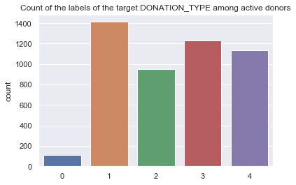

```python
%matplotlib inline
import seaborn as sns; sns.set()

# Visualizing new balance
#sns.countplot(x=activeDonors1["DONATION_TYPE"])
sns.countplot(x=y_DONATION_TYPE)
plt.title('Count of the labels of the target DONATION_TYPE among active donors')
plt.show()
```

```python
y_DONATION_TYPE=pd.DataFrame(y_DONATION_TYPE, columns=['y_DONATION_TYPE'])
y_DONATION_TYPE
```

|  | y_DONATION_TYPE |
| --- | --- |
| 0 | 3 |
| 1 | 4 |
| 2 | 2 |
| 3 | 4 |
| 4 | 3 |
| ... | ... |
| 4838 | 1 |
| 4839 | 2 |
| 4840 | 2 |
| 4841 | 3 |
| 4842 | 0 |

4843 rows × 1 columns

```python
print('Shape of X: {}'.format(multiclass_donors_final.shape))
print('Shape of y: {}'.format(y_DONATION_TYPE.shape))
```

```
Shape of X: (4843, 160)
Shape of y: (4843, 1)
```

```python
multiclass_df_final = pd.concat([multiclass_donors_final, y_DONATION_TYPE], axis=1)
```

```python
multiclass_df_final.head(3)
```

|  | CARD_PROM_12 | DONOR_AGE | FILE_CARD_GIFT | LAST_GIFT_AMT | LIFETIME_AVG_GIFT_AMT | MEDIAN_HOME_VALUE | MEDIAN_HOUSEHOLD_INCOME | MONTHS_SINCE_FIRST_GIFT | MOR_HIT_RATE | RECENT_AVG_CARD_GIFT_AMT | RECENT_AVG_GIFT_AMT | RECENT_CARD_RESPONSE_COUNT | RECENT_CARD_RESPONSE_PROP | RECENT_RESPONSE_PROP | DONOR_GENDER_A | DONOR_GENDER_F | DONOR_GENDER_M | DONOR_GENDER_U | RECENCY_STATUS_96NK_A | RECENCY_STATUS_96NK_E | RECENCY_STATUS_96NK_F | RECENCY_STATUS_96NK_L | RECENCY_STATUS_96NK_N | RECENCY_STATUS_96NK_S | HOME_OWNER_H | HOME_OWNER_U | IN_HOUSE_0 | IN_HOUSE_1 | PCT_MILITARY_0 | … |
| --- | --- | --- | --- | --- | --- | --- | --- | --- | --- | --- | --- | --- | --- | --- | --- | --- | --- | --- | --- | --- | --- | --- | --- | --- | --- | --- | --- | --- | --- | --- |
| 0 | 0.411765 | 0.903614 | 0.292683 | 0.037778 | 0.027829 | 0.035190 | 0.141333 | 0.436735 | 0.0 | 0.0750 | 0.075 | 0.222222 | 0.250 | 0.235 | 0.0 | 0.0 | 1.0 | 0.0 | 0.0 | 0.0 | 0.0 | 0.0 | 0.0 | 1.0 | 1.0 | 0.0 | 1.0 | 0.0 | 1.0 | … |
| 1 | 0.529412 | 0.903614 | 0.195122 | 0.011111 | 0.006231 | 0.149641 | 0.126000 | 0.310204 | 0.0 | 0.0250 | 0.025 | 0.444444 | 0.444 | 0.400 | 0.0 | 1.0 | 0.0 | 0.0 | 1.0 | 0.0 | 0.0 | 0.0 | 0.0 | 0.0 | 1.0 | 0.0 | 1.0 | 0.0 | 0.0 | … |
| 2 | 0.647059 | 0.710843 | 0.317073 | 0.017778 | 0.010184 | 0.046293 | 0.204667 | 0.310204 | 0.0 | 0.0425 | 0.043 | 0.444444 | 0.571 | 0.357 | 0.0 | 1.0 | 0.0 | 0.0 | 0.0 | 0.0 | 0.0 | 0.0 | 0.0 | 1.0 | 1.0 | 0.0 | 1.0 | 0.0 | 0.0 | … |

```python
multiclass_duplicateRowsDF = multiclass_df_final[multiclass_df_final.duplicated()] #checking
multiclass_duplicateRowsDF
```

|  | CARD_PROM_12 | DONOR_AGE | FILE_CARD_GIFT | LAST_GIFT_AMT | LIFETIME_AVG_GIFT_AMT | MEDIAN_HOME_VALUE | MEDIAN_HOUSEHOLD_INCOME | MONTHS_SINCE_FIRST_GIFT | MOR_HIT_RATE | RECENT_AVG_CARD_GIFT_AMT | RECENT_AVG_GIFT_AMT | RECENT_CARD_RESPONSE_COUNT | RECENT_CARD_RESPONSE_PROP | RECENT_RESPONSE_PROP | DONOR_GENDER_A | DONOR_GENDER_F | DONOR_GENDER_M | DONOR_GENDER_U | RECENCY_STATUS_96NK_A | RECENCY_STATUS_96NK_E | RECENCY_STATUS_96NK_F | RECENCY_STATUS_96NK_L | RECENCY_STATUS_96NK_N | RECENCY_STATUS_96NK_S | HOME_OWNER_H | HOME_OWNER_U | IN_HOUSE_0 | IN_HOUSE_1 | PCT_MILITARY_0 | … |
| --- | --- | --- | --- | --- | --- | --- | --- | --- | --- | --- | --- | --- | --- | --- | --- | --- | --- | --- | --- | --- | --- | --- | --- | --- | --- | --- | --- | --- | --- | --- |

```python
X = multiclass_df_final.drop(['y_DONATION_TYPE'],axis=1)
y = multiclass_df_final.y_DONATION_TYPE
```

## 1.2.2) Dealing with an unbalanced data problem

As we previously mentioned, we are facing a problem on this dataset. The problem is the unbalanced distribution of its values. So, as a way to solve the problem and prevent this from distorting the results of each of the classifiers, we will try to "equalize" the "target" to be classfied (ie: the "DONATION_TYPE").

To do so, we are going to use the SMOTE Technique.

The following code will give us a preview/comparison of the result of applying the SMOTE. We will print the before/after results after applying the SMOTE techinque:

```python
# Splitting the dataset into training and testing sets
X = multiclass_df_final.drop(['y_DONATION_TYPE'],axis=1)
y = multiclass_df_final.y_DONATION_TYPE
X_train, X_test, y_train, y_test = train_test_split(X, y, test_size = 0.20, stratify=y, random_state = 42)
smote = SMOTE()
X_sm , y_sm = smote.fit_sample(X_train, y_train)
```

```python
print("Shape of X_train: ", X_train.shape)
print("Shape of y_train: ", y_train.shape)
print("Shape of X_test: ", X_test.shape)
print("Shape of y_test: ", y_test.shape)
```

[output not shown]

```python
print('After OverSampling, the shape of train_X: {}'.format(X_sm.shape))
print('After OverSampling, the shape of train_y: {} \n'.format(y_sm.shape))
```

[output not shown]

[output not shown]

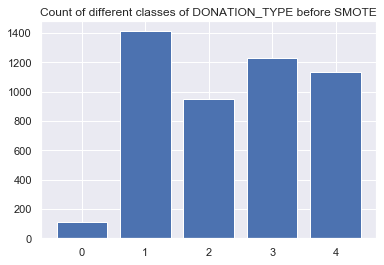

[output not shown]

```python
print('Before applying SMOTE:')
counter = Counter(multiclass_df_final.y_DONATION_TYPE)
for i in np.unique(y_DONATION_TYPE):
    print("Before OverSampling, counts of label '{}': {}".format(i, sum(y_train==i)))

pyplot.bar(counter.keys(), counter.values())
pyplot.title('Count of different classes of DONATION_TYPE before SMOTE')
pyplot.show()

print("After applying SMOTE:")
for i in np.unique(y_DONATION_TYPE):
    print("After OverSampling, counts of label '{}': {}".format(i, sum(y_sm==i)))
```

## 1.2.3) Selection of 5 classification algorithms and model construction

The choosen classifiers algorithms for each category are the following :

1) Linear model : SVM Model

2) Probabilistic model : Naive-Bayes Model

3) Tree model : Decision Tree

4) Distance-based model : KNN Model

5) Rule model : Apriori model

## 1) Linear model - SVM Model

**1.a) SVM Classifier using a one-vs-rest with an unbalanced data with 10 K-fold CV**

```python
y = label_binarize(y, classes=[0, 1, 2, 3, 4])
n_classes = y.shape[1]
X_train, X_test, y_train, y_test = train_test_split(X, y, test_size = 0.20, random_state = 42)
```

```python
svr = OneVsRestClassifier(SVC(probability=True, decision_function_shape="ovo", random_state=42))
svm_param_grid = {'estimator__C':[1, 5]}
svm_grid_search = GridSearchCV(svr, param_grid=svm_param_grid, n_jobs=-1, scoring='roc_auc', cv=KFold(n_splits=10))
```

```python
svm_grid_search.fit(X_train, y_train)
```

```
GridSearchCV(cv=KFold(n_splits=10, random_state=None, shuffle=False),
             estimator=OneVsRestClassifier(estimator=SVC(decision_function_shape='ovo',
                                                         probability=True,
                                                         random_state=42)),
             n_jobs=-1, param_grid={'estimator__C': [1, 5]}, scoring='roc_auc')
```

```python
svm_pred = svm_grid_search.predict(X_test)
```

```python
best_par(svm_grid_search) # roc score is on training set
```

```
Best Score (Area under the ROC curve)= nan
Best Parameters {'estimator__C': 1}
Best Estimator OneVsRestClassifier(estimator=SVC(C=1, decision_function_shape='ovo',
                                  probability=True, random_state=42))
```

```python
print('Avg weighted ROC score on the test set:',np.round(roc_auc_score(svm_pred, y_test, multi_class="ovo",average='weighted'),2))
```

```
Avg weighted ROC score on the test set: 0.76
```

```python
print(f"- Per Label and Average Metrics Results : \n\n{classification_report(y_test, svm_pred)}")
```

[output not shown]

```python
accuracy_test = accuracy_score(y_test, svm_pred)
print("On average, the model predicted {}% of the individuals correctly in the test set.".format(np.round(accuracy_test*100,2)))
precision_test = precision_score(y_test, svm_pred, average='weighted')
print("On average, the model predicted correctly that an individual will belong to the right DONATION_TYPE class {}% of the times in the test set.".format(np.round(precision_test*100,2)))
recall_test = recall_score(y_test,svm_pred, average='weighted')
print("On average, the model predicted belonging to a certain class, {}% of the times for passengers who actually belonged there in the test set.".format(np.round(recall_test*100,2)))
f1_test = f1_score(y_test,svm_pred, average='weighted') #F1 score can be interpreted as a weighted average of the precision and recall
    #best value F1=1, worst value F1=0
```

[output not shown]

**1.b) SVM Classifier using a one-vs-rest using SMOTE with 10 K-fold CV**

```python
smote_svm_grid_search = svm_grid_search.fit(X_sm, y_sm)
```

```python
smote_multiclass_svm_pred=smote_svm_grid_search.predict(X_test)
```

```python
print ("Best Parameters", smote_svm_grid_search.best_params_)
print ("Best Estimator",smote_svm_grid_search.best_estimator_)

print('Avg weighted ROC score on the test set:',np.round(roc_auc_score(y_test, smote_svm_grid_search.predict_proba(X_test), multi_class='ovo'),2))

print(f"Per Label and Average Metrics Results : \n\n{classification_report(y_test, smote_multiclass_svm_pred)}")
```

```
Best Parameters {'estimator__C': 1}
Best Estimator OneVsRestClassifier(estimator=SVC(C=1, decision_function_shape='ovo',
                                  probability=True, random_state=42))
Avg weighted ROC score on the test set: 0.7
Per Label and Average Metrics Results :

              precision    recall  f1-score   support

           0       0.15      0.30      0.20        33
           1       0.43      0.54      0.48       258
           2       0.31      0.15      0.20       193
           3       0.38      0.17      0.24       259
           4       0.50      0.81      0.62       226

    accuracy                           0.42       969
   macro avg       0.35      0.39      0.35       969
weighted avg       0.40      0.42      0.38       969
```

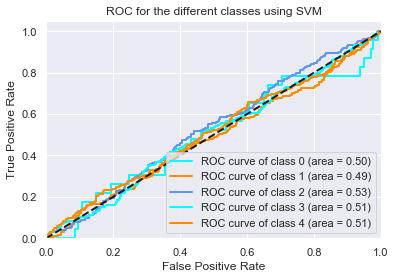

```python
fpr = dict()
tpr = dict()
roc_auc = dict()
for i in range(n_classes):
    fpr[i], tpr[i], _ = roc_curve(y_test[:, i], y_score[:, i])
    roc_auc[i] = auc(fpr[i], tpr[i])

# First aggregate all false positive rates
all_fpr = np.unique(np.concatenate([fpr[i] for i in range(n_classes)]))

# Then interpolate all ROC curves at this points
mean_tpr = np.zeros_like(all_fpr)
for i in range(n_classes):
    mean_tpr += interp(all_fpr, fpr[i], tpr[i])

# Finally average it and compute AUC
mean_tpr /= n_classes

fpr["macro"] = all_fpr
tpr["macro"] = mean_tpr
roc_auc["macro"] = auc(fpr["macro"], tpr["macro"])

# Plot all ROC curves
colors = cycle(['aqua', 'darkorange', 'cornflowerblue'])
for i, color in zip(range(n_classes), colors):
    plt.plot(fpr[i], tpr[i], color=color, lw=lw,
             label='ROC curve of class {0} (area = {1:0.2f})'
             ''.format(i, roc_auc[i]))

plt.plot([0, 1], [0, 1], 'k--', lw=lw)
plt.xlim([0.0, 1.0])
plt.ylim([0.0, 1.05])
plt.xlabel('False Positive Rate')
plt.ylabel('True Positive Rate')
plt.title('ROC for the different classes using SVM')
plt.legend(loc="lower right")
plt.show()
```

## 2) Probabilistic model - Naive-Bayes

**2.a) Naive Bayes using unbalanced data with 10 K-fold CV**

```python
#Splitting the dataset into training and testing sets
X = multiclass_df_final.drop(['y_DONATION_TYPE'],axis=1)
y = multiclass_df_final.y_DONATION_TYPE

#y = label_binarize(y, classes=[0, 1, 2, 3, 4])
#n_classes = y.shape[1]

X_train, X_test, y_train, y_test = train_test_split(X, y, test_size = 0.20, random_state = 42)
smote = SMOTE()
X_sm , y_sm = smote.fit_sample(X_train, y_train)
```

```python
nb = GaussianNB()
nb_param_grid = { 'var_smoothing' : [0.1,0.2,0.3,0.4,0.5,0.6,0.7,0.8,0.9,1]}
print('Searching for paramaters')
multiclass_nb_grid_search = GridSearchCV(nb,param_grid=nb_param_grid,cv=10, scoring='roc_auc', n_jobs=-1)
print('Fitting the model')
multiclass_nb_grid_search.fit(X_train, y_train)
```

```
Searching for paramaters
Fitting the model
```

```
GridSearchCV(cv=10, estimator=GaussianNB(), n_jobs=-1,
             param_grid={'var_smoothing': [0.1, 0.2, 0.3, 0.4, 0.5, 0.6, 0.7,
                                           0.8, 0.9, 1]},
             scoring='roc_auc')
```

```python
multiclass_nb_pred=multiclass_nb_grid_search.predict(X_test)
```

```python
print ("Best Parameters", multiclass_nb_grid_search.best_params_)
print ("Best Estimator",multiclass_nb_grid_search.best_estimator_)

print('Avg weighted ROC score on the test set:',np.round(roc_auc_score(y_test, multiclass_nb_grid_search.predict_proba(X_test), multi_class='ovo'),2))

print(f"Per Label and Average Metrics Results : \n\n{classification_report(y_test, multiclass_nb_pred)}")
```

```
Best Parameters {'var_smoothing': 0.1}
Best Estimator GaussianNB(var_smoothing=0.1)
Avg weighted ROC score on the test set: 0.65
Per Label and Average Metrics Results :

              precision    recall  f1-score   support

           0       0.13      0.24      0.17        33
           1       0.39      0.38      0.38       258
           2       0.22      0.19      0.20       193
           3       0.32      0.23      0.27       259
           4       0.47      0.62      0.54       226

    accuracy                           0.35       969
   macro avg       0.31      0.33      0.31       969
weighted avg       0.35      0.35      0.34       969
```

**2.b) Naive Bayes using SMOTE with 10 K-fold CV**

```python
smote_nb_grid_search = multiclass_nb_grid_search.fit(X_sm, y_sm)
```

```python
smote_multiclass_nb_pred=smote_nb_grid_search.predict(X_test)
```

```python
print ("Best Parameters", smote_nb_grid_search.best_params_)
print ("Best Estimator",smote_nb_grid_search.best_estimator_)

print('Avg weighted ROC score on the test set:',np.round(roc_auc_score(y_test, smote_nb_grid_search.predict_proba(X_test), multi_class='ovo'),2))

print(f"Per Label and Average Metrics Results : \n\n{classification_report(y_test, smote_multiclass_nb_pred)}")
```

```
Best Parameters {'var_smoothing': 0.1}
Best Estimator GaussianNB(var_smoothing=0.1)
Avg weighted ROC score on the test set: 0.64
Per Label and Average Metrics Results :

              precision    recall  f1-score   support

           0       0.05      0.45      0.09        33
           1       0.45      0.17      0.24       258
           2       0.24      0.24      0.24       193
           3       0.29      0.13      0.18       259
           4       0.50      0.59      0.54       226

    accuracy                           0.28       969
   macro avg       0.31      0.32      0.26       969
weighted avg       0.36      0.28      0.29       969
```

## 3) Distance-based model - KNN

**3.a) KNN using unbalanced data with 10 K-fold CV**

```python
knn = KNeighborsClassifier()
param_grid = { 'n_neighbors' : list(range(1, 20)) }

multiclass_grid_search_knn = GridSearchCV(knn,param_grid=param_grid,cv=10, scoring='roc_auc', n_jobs=-1)
multiclass_grid_search_knn.fit(X_train, y_train)
```

```
GridSearchCV(cv=10, estimator=KNeighborsClassifier(), n_jobs=-1,
             param_grid={'n_neighbors': [1, 2, 3, 4, 5, 6, 7, 8, 9, 10, 11, 12,
                                         13, 14, 15, 16, 17, 18, 19]},
             scoring='roc_auc')
```

```python
multiclass_pred_knn=multiclass_grid_search_knn.predict(X_test)
```

```python
print ("Best Parameters", multiclass_grid_search_knn.best_params_)
print ("Best Estimator",multiclass_grid_search_knn.best_estimator_)

print('Avg weighted ROC score on the test set:',np.round(roc_auc_score(y_test, multiclass_grid_search_knn.predict_proba(X_test), multi_class='ovo'),2))

print(f"Per Label and Average Metrics Results : \n\n{classification_report(y_test, multiclass_pred_knn)}")
```

```
Best Parameters {'n_neighbors': 1}
Best Estimator KNeighborsClassifier(n_neighbors=1)
Avg weighted ROC score on the test set: 0.54
Per Label and Average Metrics Results :

              precision    recall  f1-score   support

           0       0.07      0.03      0.04        33
           1       0.37      0.40      0.38       258
           2       0.20      0.20      0.20       193
           3       0.27      0.26      0.26       259
           4       0.40      0.41      0.41       226

    accuracy                           0.31       969
   macro avg       0.26      0.26      0.26       969
weighted avg       0.31      0.31      0.31       969
```

**3.b) KNN using SMOTE with 10 K-fold CV**

```python
smote_multiclass_knn_grid_search = multiclass_grid_search_knn.fit(X_sm, y_sm)
```

```python
smote_multiclass_knn_pred=smote_multiclass_knn_grid_search.predict(X_test)
```

```python
print ("Best Parameters", smote_multiclass_knn_grid_search.best_params_)
print ("Best Estimator",smote_multiclass_knn_grid_search.best_estimator_)

print('Avg weighted ROC score on the test set:',np.round(roc_auc_score(y_test, smote_multiclass_knn_grid_search.predict_proba(X_test), multi_class='ovo'),2))

print(f"Per Label and Average Metrics Results : \n\n{classification_report(y_test, smote_multiclass_knn_pred)}")
```

```
Best Parameters {'n_neighbors': 1}
Best Estimator KNeighborsClassifier(n_neighbors=1)
Avg weighted ROC score on the test set: 0.53
Per Label and Average Metrics Results :

              precision    recall  f1-score   support

           0       0.04      0.06      0.05        33
           1       0.32      0.25      0.28       258
           2       0.20      0.26      0.23       193
           3       0.28      0.26      0.27       259
           4       0.40      0.41      0.41       226

    accuracy                           0.29       969
   macro avg       0.25      0.25      0.25       969
weighted avg       0.30      0.29      0.29       969
```

## 4) Tree-based model - Decision Tree

**4.a) Decision Tree using unbalanced data with 10 K-fold CV**

```python
dt = DecisionTreeClassifier()
param_grid = { 'max_depth' : list(range(1, 10)),
             'max_features':list(range(1,50,4)),
             'criterion':list(['gini','entropy'])}
grid_search_dt= GridSearchCV(dt,param_grid=param_grid,cv=10, scoring='roc_auc', n_jobs=1)
grid_search_dt.fit(X_train, y_train)
```

[output not shown]

```python
y_pred_dt = grid_search_dt.predict(X_test)
```

```python
print ("Best Parameters", grid_search_dt.best_params_)
print ("Best Estimator",grid_search_dt.best_estimator_)

print('Avg weighted ROC score on the test set:',np.round(roc_auc_score(y_test, grid_search_dt.predict_proba(X_test), multi_class='ovo'),2))

print(f"Per Label and Average Metrics Results : \n\n{classification_report(y_test, y_pred_dt)}")
```

```
Best Parameters {'criterion': 'gini', 'max_depth': 1, 'max_features': 1}
Best Estimator DecisionTreeClassifier(max_depth=1, max_features=1)
Avg weighted ROC score on the test set: 0.5
Per Label and Average Metrics Results :

              precision    recall  f1-score   support

           0       0.00      0.00      0.00        33
           1       0.27      1.00      0.42       258
           2       0.00      0.00      0.00       193
           3       0.00      0.00      0.00       259
           4       0.00      0.00      0.00       226

    accuracy                           0.27       969
   macro avg       0.05      0.20      0.08       969
weighted avg       0.07      0.27      0.11       969
```

**4.b) Decision Tree using SMOTE with 10 K-fold CV**

```python
smote_multiclass_dt_grid_search = grid_search_dt.fit(X_sm, y_sm)
```

```python
smote_multiclass_dt_pred=smote_multiclass_dt_grid_search.predict(X_test)
```

```python
print ("Best Parameters", smote_multiclass_dt_grid_search.best_params_)
print ("Best Estimator",smote_multiclass_dt_grid_search.best_estimator_)

print('Avg weighted ROC score on the test set:',np.round(roc_auc_score(y_test, smote_multiclass_dt_grid_search.predict_proba(X_test), multi_class='ovo'),2))

print(f"Per Label and Average Metrics Results : \n\n{classification_report(y_test, smote_multiclass_dt_pred)}")
```

```
Best Parameters {'criterion': 'gini', 'max_depth': 1, 'max_features': 1}
Best Estimator DecisionTreeClassifier(max_depth=1, max_features=1)
Avg weighted ROC score on the test set: 0.5
Per Label and Average Metrics Results :

              precision    recall  f1-score   support

           0       0.03      1.00      0.07        33
           1       0.00      0.00      0.00       258
           2       0.00      0.00      0.00       193
           3       0.00      0.00      0.00       259
           4       0.00      0.00      0.00       226

    accuracy                           0.03       969
   macro avg       0.01      0.20      0.01       969
weighted avg       0.00      0.03      0.00       969
```

## 5) Rule model - Apriori Algorithm

```python
activeDonors = activedonors.copy()
activeDonors.shape  # --> The value of i and j will be  4665 and  42
```

```
(4843, 30)
```

```python
transactions = []
for i in range(0, activeDonors.shape[0]):
    transactions.append([str(activeDonors.values[i, j]) for j in range(0, 42)])
```

```python
association_rules = apriori(transactions, min_support=0.2, min_confidence=0.2, min_lift=3, min_length=2)
# we convert the rules found by the apriori class into a list since it is easier to view the results in this form
association_results = list(association_rules)
```

```python
print(len(list(association_results)))
```

[output not shown]

```python
print(list(association_results))
```

[output not shown]

```python
association_rules = apriori(transactions, min_support=0.045, min_confidence=0.2, min_lift=3, min_length=2)
association_results = list(association_rules)
```

```python
print(association_results)
```

```
[RelationRecord(items=frozenset({'3.0', '3', '10.0', '7.0'}), support=0.045444801714898175, ordered_statistics=[OrderedStatistic(items_base=frozenset({'3.0', '10.0'}), items_add=frozenset({'3', '7.0'}), confidence=0.41487279843444225, lift=3.1418532543777165), OrderedStatistic(items_base=frozenset({…
```

```python
### The list of  Rules/Relations are these :

for item in association_results:

    pair = item[0]
    items = [x for x in pair]
    print("Regra: " + items[0] + " <-> " + items[1])
    print("  Support: " + str(item[1]))
    print("  Confidence: " + str(item[2][0][2]))
    print("  Lift: " + str(item[2][0][3]))
    print("=====================================")
    print("=====================================")
```

```
Regra: 3.0 <-> 3
  Support: 0.045444801714898175
  Confidence: 0.41487279843444225
  Lift: 3.1418532543777165
=====================================
=====================================
Regra: 10.0 <-> 3.0
  Support: 0.045444801714898175
  Confidence: 0.41487279843444225
  Lift: 3.1418532543777165
=====================================
=====================================
Regra: 10.0 <-> 1
  Support: 0.04501607717041801
  Confidence: 0.410958904109589
  Lift: 3.147985694041433
=====================================
=====================================
Regra: 10.0 <-> 1
  Support: 0.04501607717041801
  Confidence: 0.410958904109589
  Lift: 3.147985694041433
=====================================
=====================================
```

```python
print(association_results[0])
```

```
RelationRecord(items=frozenset({'3.0', '3', '10.0', '7.0'}), support=0.045444801714898175, ordered_statistics=[OrderedStatistic(items_base=frozenset({'3.0', '10.0'}), items_add=frozenset({'3', '7.0'}), confidence=0.41487279843444225, lift=3.1418532543777165), OrderedStatistic(items_base=frozenset({'…
```

```python
print(association_results)
```

```
[RelationRecord(items=frozenset({'3.0', '3', '10.0', '7.0'}), support=0.045444801714898175, ordered_statistics=[OrderedStatistic(items_base=frozenset({'3.0', '10.0'}), items_add=frozenset({'3', '7.0'}), confidence=0.41487279843444225, lift=3.1418532543777165), OrderedStatistic(items_base=frozenset({…
```

## Task 1.3) Training specialized models for SES (socioeconomic classification) - SES

```python
donors["SES"].unique()
```

```
array([2., 1., 3., 4.])
```

```python
donors_cat = ['DONOR_GENDER','RECENCY_STATUS_96NK','HOME_OWNER', 'IN_HOUSE',
                    "PCT_MILITARY", "PCT_VETERANS",
                    'PUBLISHED_PHONE',
                    'URBANICITY', 'SES']
```

```python
encoder = OneHotEncoder(handle_unknown='ignore',sparse=False)
cat_features_final = encoder.fit_transform(donors[donors_cat])
column_name = encoder.get_feature_names(donors_cat)
one_hot_encoded_cat =  pd.DataFrame(cat_features_final, columns= column_name)
print(one_hot_encoded_cat.shape)
```

```
(19372, 179)
```

```python
# num features - scalling
numericalfeatures = ['CARD_PROM_12','DONOR_AGE','FILE_CARD_GIFT',
                    'LAST_GIFT_AMT','LIFETIME_AVG_GIFT_AMT','MEDIAN_HOME_VALUE',
                    'MEDIAN_HOUSEHOLD_INCOME','MONTHS_SINCE_FIRST_GIFT',
                    'MOR_HIT_RATE', 'RECENT_AVG_CARD_GIFT_AMT','RECENT_AVG_GIFT_AMT',
                    'RECENT_CARD_RESPONSE_COUNT','RECENT_CARD_RESPONSE_PROP','RECENT_RESPONSE_PROP']
```

```python
donors_num = donors[numericalfeatures]
scaler = MinMaxScaler()
scaled = scaler.fit_transform(donors_num)

# creating a scaled dataframe
donors_num_scaled = pd.DataFrame(scaled)
donors_num_scaled.columns = donors_num.columns
```

```python
df3_donors_final = pd.concat([donors_num_scaled, one_hot_encoded_cat], axis=1)
```

```python
df3_donors_final= df3_donors_final.sort_index(ascending=True)
```

```python
df3_donors_final[['SES_1.0','SES_2.0','SES_3.0','SES_4.0']]
```

|  | SES_1.0 | SES_2.0 | SES_3.0 | SES_4.0 |
| --- | --- | --- | --- | --- |
| 0 | 0.0 | 1.0 | 0.0 | 0.0 |
| 1 | 0.0 | 1.0 | 0.0 | 0.0 |
| 2 | 1.0 | 0.0 | 0.0 | 0.0 |
| 3 | 0.0 | 1.0 | 0.0 | 0.0 |
| 4 | 0.0 | 1.0 | 0.0 | 0.0 |
| ... | ... | ... | ... | ... |
| 19367 | 1.0 | 0.0 | 0.0 | 0.0 |
| 19368 | 1.0 | 0.0 | 0.0 | 0.0 |
| 19369 | 1.0 | 0.0 | 0.0 | 0.0 |
| 19370 | 0.0 | 1.0 | 0.0 | 0.0 |
| 19371 | 0.0 | 1.0 | 0.0 | 0.0 |

19372 rows × 4 columns

```python
y_SES_TARGET_B = donors.TARGET_B
y_SES_TARGET_B
```

```
0        0
1        1
2        0
3        0
4        0
        ..
19367    0
19368    0
19369    0
19370    0
19371    1
Name: TARGET_B, Length: 19372, dtype: int64
```

```python
print('Shape of X: {}'.format(df3_donors_final.shape))
print('Shape of y: {}'.format(y_SES_TARGET_B.shape))
```

```
Shape of X: (19372, 193)
Shape of y: (19372,)
```

**3.1) SES 1 - TARGET_B prediction**

```python
SES1_list = df3_donors_final.loc[df3_donors_final['SES_1.0'] == 1.0].index.tolist()

y = y_SES_TARGET_B[SES1_list]

X = df3_donors_final.loc[df3_donors_final['SES_1.0'] == 1.0]
X = X.drop(['SES_1.0','SES_2.0','SES_3.0','SES_4.0'],axis=1)

X_train, X_test, y_train, y_test = train_test_split(X, y, test_size=0.2, random_state=42)
```

```python
nb = GaussianNB(var_smoothing=0.6) #using the best parameters found in the previous task

nb.fit(X_train, y_train)

y_pred_nb = nb.predict(X_test)
```

```
ROC =  0.59
```

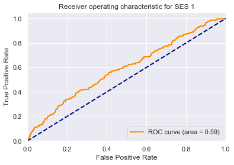

```python
y_predict_proba = nb.predict_proba(X_test)[:,1]
fpr, tpr, thresholds = roc_curve(y_test, y_predict_proba)
roc_auc = auc(fpr, tpr)
print('ROC = ', np.round(roc_auc,2))
plt.figure()
lw = 2
plt.plot(fpr, tpr, color='darkorange',
         lw=lw, label='ROC curve (area = %0.2f)' % roc_auc)
plt.plot([0, 1], [0, 1], color='navy', lw=lw, linestyle='--')
plt.xlim([0.0, 1.0])
plt.ylim([0.0, 1.05])
plt.xlabel('False Positive Rate')
plt.ylabel('True Positive Rate')
plt.title('Receiver operating characteristic for SES 1')
plt.legend(loc="lower right")
plt.show()
```

**3.2) SES 2 - TARGET_B prediction**

```python
SES2_list = df3_donors_final.loc[df3_donors_final['SES_2.0'] == 1.0].index.tolist()

y = y_SES_TARGET_B[SES2_list]

X = df3_donors_final.loc[df3_donors_final['SES_2.0'] == 1.0]
X = X.drop(['SES_1.0','SES_2.0','SES_3.0','SES_4.0'],axis=1)

X_train, X_test, y_train, y_test = train_test_split(X, y, test_size=0.2, random_state=42)
```

```python
nb = GaussianNB(var_smoothing=0.6) #using the best parameters found in the previous task

nb.fit(X_train, y_train)

y_pred_nb = nb.predict(X_test)
```

```
ROC =  0.57
```

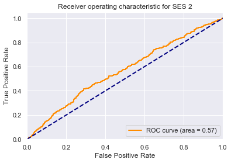

```python
y_predict_proba = nb.predict_proba(X_test)[:,1]
fpr, tpr, thresholds = roc_curve(y_test, y_predict_proba)
roc_auc = auc(fpr, tpr)
print('ROC = ', np.round(roc_auc,2))
plt.figure()
lw = 2
plt.plot(fpr, tpr, color='darkorange',
         lw=lw, label='ROC curve (area = %0.2f)' % roc_auc)
plt.plot([0, 1], [0, 1], color='navy', lw=lw, linestyle='--')
plt.xlim([0.0, 1.0])
plt.ylim([0.0, 1.05])
plt.xlabel('False Positive Rate')
plt.ylabel('True Positive Rate')
plt.title('Receiver operating characteristic for SES 2')
plt.legend(loc="lower right")
plt.show()
```

**3.3) SES 3 - TARGET_B prediction**

```python
SES3_list = df3_donors_final.loc[df3_donors_final['SES_3.0'] == 1.0].index.tolist()

y = y_SES_TARGET_B[SES3_list]

X = df3_donors_final.loc[df3_donors_final['SES_3.0'] == 1.0]
X = X.drop(['SES_1.0','SES_2.0','SES_3.0','SES_4.0'],axis=1)

X_train, X_test, y_train, y_test = train_test_split(X, y, test_size=0.2, random_state=42)
```

```python
nb = GaussianNB(var_smoothing=0.6) #using the best parameters found in the previous task

nb.fit(X_train, y_train)

y_pred_nb = nb.predict(X_test)
```

```
ROC =  0.57
```

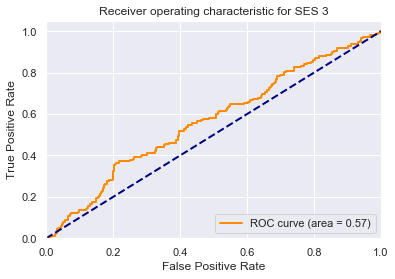

```python
y_predict_proba = nb.predict_proba(X_test)[:,1]
fpr, tpr, thresholds = roc_curve(y_test, y_predict_proba)
roc_auc = auc(fpr, tpr)
print('ROC = ', np.round(roc_auc,2))
plt.figure()
lw = 2
plt.plot(fpr, tpr, color='darkorange',
         lw=lw, label='ROC curve (area = %0.2f)' % roc_auc)
plt.plot([0, 1], [0, 1], color='navy', lw=lw, linestyle='--')
plt.xlim([0.0, 1.0])
plt.ylim([0.0, 1.05])
plt.xlabel('False Positive Rate')
plt.ylabel('True Positive Rate')
plt.title('Receiver operating characteristic for SES 3')
plt.legend(loc="lower right")
plt.show()
```

**3.4) SES 4 - TARGET_B prediction**

```python
SES4_list = df3_donors_final.loc[df3_donors_final['SES_4.0'] == 1.0].index.tolist()

y = y_SES_TARGET_B[SES4_list]

X = df3_donors_final.loc[df3_donors_final['SES_4.0'] == 1.0]
X = X.drop(['SES_1.0','SES_2.0','SES_3.0','SES_4.0'],axis=1)

X_train, X_test, y_train, y_test = train_test_split(X, y, test_size=0.2, random_state=42)
```

```python
nb = GaussianNB(var_smoothing=0.6) #using the best parameters found in the previous task

nb.fit(X_train, y_train)

y_pred_nb = nb.predict(X_test)
```

```
ROC =  0.52
```

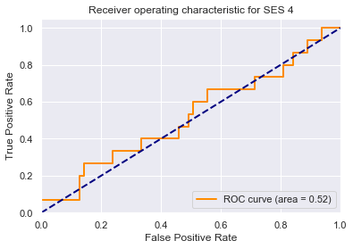

```python
y_predict_proba = nb.predict_proba(X_test)[:,1]
fpr, tpr, thresholds = roc_curve(y_test, y_predict_proba)
roc_auc = auc(fpr, tpr)
print('ROC = ', np.round(roc_auc,2))
plt.figure()
lw = 2
plt.plot(fpr, tpr, color='darkorange',
         lw=lw, label='ROC curve (area = %0.2f)' % roc_auc)
plt.plot([0, 1], [0, 1], color='navy', lw=lw, linestyle='--')
plt.xlim([0.0, 1.0])
plt.ylim([0.0, 1.05])
plt.xlabel('False Positive Rate')
plt.ylabel('True Positive Rate')
plt.title('Receiver operating characteristic for SES 4')
plt.legend(loc="lower right")
plt.show()
```

# Task 2 (Unsupervised Learning) - Characterizing Donors and Donation Type

In this task you should **use unsupervised learning algorithms and try to characterize donors (people who really did a donation) and their donation type**. You can use:

- **Association rule mining** to find **associations between the features and the target Donation/DonationTYPE**.
- **Clustering algorithms to find similar groups of donors**. Is it possible to find groups of donors with the same/similar DonationTYPE?
- **Be creative and define your own unsupervised analysis!** What would it be interesting to find out ?

```python
donors.head(5)
```

|  | TARGET_B | TARGET_D | DONOR_AGE | IN_HOUSE | URBANICITY | SES | HOME_OWNER | DONOR_GENDER | PUBLISHED_PHONE | MOR_HIT_RATE | MEDIAN_HOME_VALUE | MEDIAN_HOUSEHOLD_INCOME | PCT_OWNER_OCCUPIED | PCT_MILITARY | PCT_VETERANS | RECENCY_STATUS_96NK | FREQUENCY_STATUS_97NK | RECENT_RESPONSE_PROP | RECENT_AVG_GIFT_AMT | RECENT_CARD_RESPONSE_PROP | RECENT_AVG_CARD_GIFT_AMT | RECENT_CARD_RESPONSE_COUNT | MONTHS_SINCE_LAST_PROM_RESP | LIFETIME_AVG_GIFT_AMT | LAST_GIFT_AMT | CARD_PROM_12 | MONTHS_SINCE_LAST_GIFT | MONTHS_SINCE_FIRST_GIFT | FILE_CARD_GIFT | … |
| --- | --- | --- | --- | --- | --- | --- | --- | --- | --- | --- | --- | --- | --- | --- | --- | --- | --- | --- | --- | --- | --- | --- | --- | --- | --- | --- | --- | --- | --- | --- |
| 0 | 0 | NaN | 87.0 | 0 | S | 2 | H | M | 0 | 0 | 554.0 | 294 | 76 | 0 | 0 | A | 1 | 0.067 | 15.00 | 0.000 | 0.00 | 0 | 26 | 8.49 | 15.0 | 5 | 26 | 92 | 7 | … |
| 1 | 1 | 10.0 | 79.0 | 0 | R | 2 | H | M | 0 | 0 | 334.0 | 212 | 72 | 0 | 41 | S | 2 | 0.235 | 15.00 | 0.250 | 15.00 | 2 | 11 | 14.72 | 17.0 | 7 | 7 | 122 | 12 | … |
| 2 | 0 | NaN | 75.0 | 0 | S | 1 | H | F | 0 | 0 | 2388.0 | 405 | 63 | 0 | 25 | S | 3 | 0.409 | 21.67 | 0.545 | 22.67 | 6 | 14 | 16.75 | 19.0 | 11 | 6 | 105 | 16 | … |
| 3 | 0 | NaN | 60.0 | 0 | U | 2 | H | F | 1 | 0 | 1688.0 | 153 | 3 | 0 | 25 | A | 3 | 0.474 | 13.44 | 0.400 | 13.50 | 4 | 11 | 11.76 | 15.0 | 11 | 6 | 92 | 12 | … |
| 4 | 0 | NaN | 74.0 | 0 | R | 2 | U | F | 1 | 1 | 514.0 | 328 | 90 | 0 | 33 | A | 1 | 0.100 | 17.50 | 0.111 | 10.00 | 1 | 18 | 8.83 | 25.0 | 6 | 18 | 92 | 3 | … |

```python
donors.info()
```

```
<class 'pandas.core.frame.DataFrame'>
RangeIndex: 19372 entries, 0 to 19371
Data columns (total 30 columns):
 #   Column                       Non-Null Count  Dtype
---  ------                       --------------  -----
 0   TARGET_B                     19372 non-null  category
 1   TARGET_D                     4843 non-null   float64
 2   DONOR_AGE                    19372 non-null  float64
 3   IN_HOUSE                     19372 non-null  category
 4   URBANICITY                   19372 non-null  category
 5   SES                          19372 non-null  category
 6   HOME_OWNER                   19372 non-null  category
 7   DONOR_GENDER                 19372 non-null  category
 8   PUBLISHED_PHONE              19372 non-null  category
 9   MOR_HIT_RATE                 19372 non-null  category
```

[output cut: 22 more lines]

## 2.1. Preprocessing Data for Association Rule Mining

```python
activedonors.head(2)
```

|  | TARGET_B | TARGET_D | DONOR_AGE | IN_HOUSE | URBANICITY | SES | HOME_OWNER | DONOR_GENDER | PUBLISHED_PHONE | MOR_HIT_RATE | MEDIAN_HOME_VALUE | MEDIAN_HOUSEHOLD_INCOME | PCT_OWNER_OCCUPIED | PCT_MILITARY | PCT_VETERANS | RECENCY_STATUS_96NK | FREQUENCY_STATUS_97NK | RECENT_RESPONSE_PROP | RECENT_AVG_GIFT_AMT | RECENT_CARD_RESPONSE_PROP | RECENT_AVG_CARD_GIFT_AMT | RECENT_CARD_RESPONSE_COUNT | MONTHS_SINCE_LAST_PROM_RESP | LIFETIME_AVG_GIFT_AMT | LAST_GIFT_AMT | CARD_PROM_12 | MONTHS_SINCE_LAST_GIFT | MONTHS_SINCE_FIRST_GIFT | FILE_CARD_GIFT | … |
| --- | --- | --- | --- | --- | --- | --- | --- | --- | --- | --- | --- | --- | --- | --- | --- | --- | --- | --- | --- | --- | --- | --- | --- | --- | --- | --- | --- | --- | --- | --- |
| 1 | 1 | 10.0 | 79.0 | 0 | R | 2 | H | M | 0 | 0 | 334.0 | 212 | 72 | 0 | 41 | S | 2 | 0.235 | 15.0 | 0.250 | 15.0 | 2 | 11 | 14.72 | 17.0 | 7 | 7 | 122 | 12 | … |
| 7 | 1 | 5.0 | 79.0 | 0 | C | 2 | H | F | 0 | 0 | 1004.0 | 189 | 95 | 3 | 44 | A | 4 | 0.400 | 5.0 | 0.444 | 5.0 | 4 | 12 | 5.05 | 5.0 | 9 | 9 | 91 | 8 | … |

```python
activeDonors2 = activedonors.drop("TARGET_D", axis=1)
activeDonors2.head(2)
```

|  | TARGET_B | DONOR_AGE | IN_HOUSE | URBANICITY | SES | HOME_OWNER | DONOR_GENDER | PUBLISHED_PHONE | MOR_HIT_RATE | MEDIAN_HOME_VALUE | MEDIAN_HOUSEHOLD_INCOME | PCT_OWNER_OCCUPIED | PCT_MILITARY | PCT_VETERANS | RECENCY_STATUS_96NK | FREQUENCY_STATUS_97NK | RECENT_RESPONSE_PROP | RECENT_AVG_GIFT_AMT | RECENT_CARD_RESPONSE_PROP | RECENT_AVG_CARD_GIFT_AMT | RECENT_CARD_RESPONSE_COUNT | MONTHS_SINCE_LAST_PROM_RESP | LIFETIME_AVG_GIFT_AMT | LAST_GIFT_AMT | CARD_PROM_12 | MONTHS_SINCE_LAST_GIFT | MONTHS_SINCE_FIRST_GIFT | FILE_CARD_GIFT | DONATION_TYPE |
| --- | --- | --- | --- | --- | --- | --- | --- | --- | --- | --- | --- | --- | --- | --- | --- | --- | --- | --- | --- | --- | --- | --- | --- | --- | --- | --- | --- | --- | --- |
| 1 | 1 | 79.0 | 0 | R | 2 | H | M | 0 | 0 | 334.0 | 212 | 72 | 0 | 41 | S | 2 | 0.235 | 15.0 | 0.250 | 15.0 | 2 | 11 | 14.72 | 17.0 | 7 | 7 | 122 | 12 | D |
| 7 | 1 | 79.0 | 0 | C | 2 | H | F | 0 | 0 | 1004.0 | 189 | 95 | 3 | 44 | A | 4 | 0.400 | 5.0 | 0.444 | 5.0 | 4 | 12 | 5.05 | 5.0 | 9 | 9 | 91 | 8 | E |

### Converting every value to string

There are currently non-string values in the values list. We also should translate 'numerical' strings to labels that can be understood without looking at the dataframe.

```python
def numVars(df):
    '''
    Returns a list of all the numerical features of a dataframe - df.
    '''
    numVars = []
    for col in df.columns:
        if df[col].dtype.name != "category":
            numVars.append(col)
    return numVars
```

```python
def catVars(df):
    '''
    Returns a list of all the categorical features of a dataframe - df.
    '''
    catVars = []
    for col in df.columns:
        if df[col].dtype.name == "category":
            catVars.append(col)
    return catVars
```

```python
activeCat = activeDonors2[catVars(activeDonors2)]
vals = activeCat.values.tolist()
```

```python
idx=0
catDict={}
for col in activeCat.columns:
    catDict[idx]=col
    idx+=1
catDict
```

```
{0: 'TARGET_B',
 1: 'IN_HOUSE',
 2: 'URBANICITY',
 3: 'SES',
 4: 'HOME_OWNER',
 5: 'DONOR_GENDER',
 6: 'PUBLISHED_PHONE',
 7: 'MOR_HIT_RATE',
 8: 'RECENCY_STATUS_96NK',
 9: 'FREQUENCY_STATUS_97NK',
 10: 'DONATION_TYPE'}
```

```python
for row in vals:
    for i in range(len(row)):
        row[i] = str(row[i])
vals[0]
```

```
['1', '0', 'R', '2', 'H', 'M', '0', '0', 'S', '2', 'D']
```

```python
# target-b values - i=0
for item in vals:
    if item[0] == '1':
        item[0] = 'donor'
    else:
        item[0] = 'non-donor'
```

```python
# in-house values - i=1
for item in vals:
    if item[1] == '1':
        item[1] = 'inhouse'
    else:
        item[1] = 'not-inhouse'
```

```python
# urbanicity values - C, R, S, U, T - i=2
for item in vals:
    if item[2] == 'C':
        item[2] = 'city'
    elif item[2] == 'R':
        item[2] = 'rural'
    elif item[2] == 'T':
        item[2] = 'town'
    elif item[2] == 'S':
        item[2] = 'suburban'
    else:
        item[2] = 'urban'
```

```python
# ses values - i=3
for item in vals:
    if item[3] == '1':
        item[3] = 'ses1'
    elif item[3] == '2':
        item[3] = 'ses2'
    elif item[3] == '3':
        item[3] = 'ses3'
    else:
        item[3] = 'ses4'
```

```python
# home-owner values - i=4
for item in vals:
    if item[4] == 'H':
        item[4] = 'homeowner'
    else:
        item[4] = 'unknown'
```

```python
# donor_gender values - i=5
for item in vals:
    if item[5] == 'M':
        item[5] = 'male'
    elif item[5] == 'F':
        item[5] = 'female'
    else:
        item[5] = 'unknown'
```

```python
# published_phone values - i=6
for item in vals:
    if item[6] == '0':
        item[6] = 'not_published'
    else:
        item[6] = 'published_phone'
```

```python
# mor_hit_rate - i=7
for item in vals:
    if item[7] == '0':
        item[7] = 'other_non_donor'
    else:
        item[7] = 'other_donor'
```

```python
# recency-status - S, A, F, N, E, L - i=8
for item in vals:
    if item[8] == 'S':
        item[8] = 'star'
    elif item[8] == 'A':
        item[8] = 'active'
    elif item[8] == 'F':
        item[8] = 'first-time'
    elif item[8] == 'N':
        item[8] = 'new'
    elif item[8] == 'E':
        item[8] = 'inactive'
    else:
        item[8] = 'lapsing'
```

```python
# frequency status values - i=9
for item in vals:
    if item[9] == '1':
        item[9] = '1_donation'
    elif item[9] == '2':
        item[9] = '2_donations'
    elif item[9] == '3':
        item[9] = '3_donations'
    else:
        item[9] = '4+_donations'
```

```python
vals[0]
```

```
['donor',
 'not-inhouse',
 'rural',
 'ses2',
 'homeowner',
 'male',
 'not_published',
 'other_non_donor',
 'star',
 '2_donations',
 'D']
```

## 2.2. Finding Associations

### Transforming vals dataframe to a binary database

```python
from mlxtend.preprocessing import TransactionEncoder
te = TransactionEncoder()
te_ary = te.fit(vals).transform(vals)
binary_database = pd.DataFrame(te_ary, columns=te.columns_)
binary_database
```

|  | 1_donation | 2_donations | 3_donations | 4+_donations | A | B | C | D | E | active | city | donor | female | first-time | homeowner | inactive | inhouse | lapsing | male | new | not-inhouse | not_published | other_donor | other_non_donor | published_phone | rural | ses1 | ses2 | ses3 | … |
| --- | --- | --- | --- | --- | --- | --- | --- | --- | --- | --- | --- | --- | --- | --- | --- | --- | --- | --- | --- | --- | --- | --- | --- | --- | --- | --- | --- | --- | --- | --- |
| 0 | False | True | False | False | False | False | False | True | False | False | False | True | False | False | True | False | False | False | True | False | True | True | False | True | False | True | False | True | False | … |
| 1 | False | False | False | True | False | False | False | False | True | True | True | True | True | False | True | False | False | False | False | False | True | True | False | True | False | False | False | True | False | … |
| 2 | False | False | True | False | False | False | True | False | False | False | False | True | True | False | True | False | False | False | False | False | True | False | False | True | True | True | False | True | False | … |
| 3 | False | True | False | False | False | False | False | False | True | False | False | True | True | False | False | False | False | False | False | False | True | False | False | True | True | True | False | True | False | … |
| 4 | False | False | False | True | False | False | False | True | False | True | False | True | False | False | False | False | False | False | True | False | True | False | True | False | True | True | False | True | False | … |
| ... | ... | ... | ... | ... | ... | ... | ... | ... | ... | ... | ... | ... | ... | ... | ... | ... | ... | ... | ... | ... | ... | ... | ... | ... | ... | ... | ... | ... | ... | … |
| 4838 | False | True | False | False | False | True | False | False | False | True | False | True | True | False | False | False | False | False | False | False | True | False | True | False | True | False | False | True | False | … |
| 4839 | False | False | True | False | False | False | True | False | False | True | False | True | False | False | False | False | False | False | False | False | True | True | False | True | False | False | False | True | False | … |
| 4840 | True | False | False | False | False | False | True | False | False | True | False | True | True | False | False | False | True | False | False | False | False | False | True | False | True | False | False | True | False | … |
| 4841 | False | True | False | False | False | False | False | True | False | True | False | True | False | False | False | False | True | False | True | False | False | True | False | True | False | False | True | False | False | … |
| 4842 | True | False | False | False | True | False | False | False | False | False | False | True | False | False | False | False | False | False | True | True | True | False | True | False | True | False | False | True | False | … |

4843 rows × 35 columns

```python
df_A = binary_database[binary_database['A']==True].drop('donor', axis=1)
df_B = binary_database[binary_database['B']==True].drop('donor', axis=1)
df_C = binary_database[binary_database['C']==True].drop('donor', axis=1)
df_D = binary_database[binary_database['D']==True].drop('donor', axis=1)
df_E = binary_database[binary_database['E']==True].drop('donor', axis=1)
```

### Identifying frequent itemsets using Apriori

```python
from mlxtend.frequent_patterns import apriori

binary_database = binary_database.drop(['A', 'B', 'C', 'D', 'E'], axis=1)

#Compute itemsets with min_support = 50%
frequent_itemsets = apriori(binary_database, min_support=0.5, use_colnames=True)
```

```python
frequent_itemsets_A = apriori(df_A, min_support=0.5, use_colnames=True)
frequent_itemsets_B = apriori(df_B, min_support=0.5, use_colnames=True)
frequent_itemsets_C = apriori(df_C, min_support=0.5, use_colnames=True)
frequent_itemsets_D = apriori(df_D, min_support=0.5, use_colnames=True)
frequent_itemsets_E = apriori(df_E, min_support=0.5, use_colnames=True)
```

## 2.3 Association Rules - Results and Discussion

```python
from mlxtend.frequent_patterns import association_rules
# Generate association rules with confidence >= 90%
rules = association_rules(frequent_itemsets, metric="confidence", min_threshold=0.9)
rules
```

|  | antecedents | consequents | antecedent support | consequent support | support | confidence | lift | leverage | conviction |
| --- | --- | --- | --- | --- | --- | --- | --- | --- | --- |
| 0 | (active) | (donor) | 0.576915 | 1.000000 | 0.576915 | 1.000000 | 1.000000 | 0.000000 | inf |
| 1 | (active) | (not-inhouse) | 0.576915 | 0.908321 | 0.525294 | 0.910523 | 1.002423 | 0.001270 | 1.024601 |
| 2 | (female) | (donor) | 0.538716 | 1.000000 | 0.538716 | 1.000000 | 1.000000 | 0.000000 | inf |
| 3 | (homeowner) | (donor) | 0.559158 | 1.000000 | 0.559158 | 1.000000 | 1.000000 | 0.000000 | inf |
| 4 | (donor) | (not-inhouse) | 1.000000 | 0.908321 | 0.908321 | 0.908321 | 1.000000 | 0.000000 | 1.000000 |
| 5 | (not-inhouse) | (donor) | 0.908321 | 1.000000 | 0.908321 | 1.000000 | 1.000000 | 0.000000 | inf |
| 6 | (not_published) | (donor) | 0.505059 | 1.000000 | 0.505059 | 1.000000 | 1.000000 | 0.000000 | inf |
| 7 | (other_non_donor) | (donor) | 0.568449 | 1.000000 | 0.568449 | 1.000000 | 1.000000 | 0.000000 | inf |
| 8 | (ses2) | (donor) | 0.507537 | 1.000000 | 0.507537 | 1.000000 | 1.000000 | 0.000000 | inf |
| 9 | (homeowner) | (not-inhouse) | 0.559158 | 0.908321 | 0.514144 | 0.919498 | 1.012305 | 0.006249 | 1.138835 |
| 10 | (other_non_donor) | (not-inhouse) | 0.568449 | 0.908321 | 0.522403 | 0.918997 | 1.011754 | 0.006069 | 1.131800 |
| 11 | (active, donor) | (not-inhouse) | 0.576915 | 0.908321 | 0.525294 | 0.910523 | 1.002423 | 0.001270 | 1.024601 |
| 12 | (active, not-inhouse) | (donor) | 0.525294 | 1.000000 | 0.525294 | 1.000000 | 1.000000 | 0.000000 | inf |
| 13 | (active) | (donor, not-inhouse) | 0.576915 | 0.908321 | 0.525294 | 0.910523 | 1.002423 | 0.001270 | 1.024601 |
| 14 | (donor, homeowner) | (not-inhouse) | 0.559158 | 0.908321 | 0.514144 | 0.919498 | 1.012305 | 0.006249 | 1.138835 |
| 15 | (not-inhouse, homeowner) | (donor) | 0.514144 | 1.000000 | 0.514144 | 1.000000 | 1.000000 | 0.000000 | inf |
| 16 | (homeowner) | (donor, not-inhouse) | 0.559158 | 0.908321 | 0.514144 | 0.919498 | 1.012305 | 0.006249 | 1.138835 |
| 17 | (donor, other_non_donor) | (not-inhouse) | 0.568449 | 0.908321 | 0.522403 | 0.918997 | 1.011754 | 0.006069 | 1.131800 |
| 18 | (not-inhouse, other_non_donor) | (donor) | 0.522403 | 1.000000 | 0.522403 | 1.000000 | 1.000000 | 0.000000 | inf |
| 19 | (other_non_donor) | (donor, not-inhouse) | 0.568449 | 0.908321 | 0.522403 | 0.918997 | 1.011754 | 0.006069 | 1.131800 |

```python
# add new column length
frequent_itemsets['length'] = frequent_itemsets['itemsets'].apply(lambda x: len(x))
frequent_itemsets

# filter using pattern length = 2
frequent_2_itemsets = frequent_itemsets[frequent_itemsets['length'] == 2]
frequent_2_itemsets.sort_values('support', ascending=False)
```

|  | support | itemsets | length |
| --- | --- | --- | --- |
| 12 | 0.908321 | (donor, not-inhouse) | 2 |
| 8 | 0.576915 | (active, donor) | 2 |
| 14 | 0.568449 | (donor, other_non_donor) | 2 |
| 11 | 0.559158 | (donor, homeowner) | 2 |
| 10 | 0.538716 | (donor, female) | 2 |
| 9 | 0.525294 | (active, not-inhouse) | 2 |
| 17 | 0.522403 | (not-inhouse, other_non_donor) | 2 |
| 16 | 0.514144 | (not-inhouse, homeowner) | 2 |
| 15 | 0.507537 | (donor, ses2) | 2 |
| 13 | 0.505059 | (not_published, donor) | 2 |

After rule association mining, we can identify some associations for `TARGET_B`:

- `IN_HOUSE`: people who have NEVER donated to the in-house program are more likely to donate.
- `DONOR_GENDER`: women are more likely to donate.
- `MOR_HIT_RATE`: people who never responded to another charity's mail are more likely to donate.
- `RECENCY_STATUS_96NK`: active donors are more likely to donate.
- `HOME_OWNER`: homeowners are more likely to donate.
- `PUBLISHED_PHONE`: people who do NOT have their phone published are more likely to donate.
- `SES`: people who belong to SES group 2 are more likely to donate.

```python
rules_A = association_rules(frequent_itemsets_A, metric="confidence", min_threshold=0.9)

# add new column length
frequent_itemsets_A['length'] = frequent_itemsets_A['itemsets'].apply(lambda x: len(x))
frequent_itemsets_A

# filter using pattern length = 2
frequent_2_itemsets_A = frequent_itemsets_A[frequent_itemsets_A['length'] == 2]
frequent_2_itemsets_A.sort_values('support', ascending=False)
```

|  | support | itemsets | length |
| --- | --- | --- | --- |
| 9 | 0.833333 | (not-inhouse, A) | 2 |
| 8 | 0.684211 | (active, A) | 2 |
| 11 | 0.631579 | (other_non_donor, A) | 2 |
| 7 | 0.614035 | (A, 1_donation) | 2 |
| 14 | 0.570175 | (not-inhouse, other_non_donor) | 2 |
| 13 | 0.561404 | (active, not-inhouse) | 2 |
| 10 | 0.552632 | (not_published, A) | 2 |
| 12 | 0.526316 | (A, unknown) | 2 |

```python
rules_B = association_rules(frequent_itemsets_B, metric="confidence", min_threshold=0.9)

# add new column length
frequent_itemsets_B['length'] = frequent_itemsets_B['itemsets'].apply(lambda x: len(x))
frequent_itemsets_B

# filter using pattern length = 2
frequent_2_itemsets_B = frequent_itemsets_B[frequent_itemsets_B['length'] == 2]
frequent_2_itemsets_B.sort_values('support', ascending=False)
```

|  | support | itemsets | length |
| --- | --- | --- | --- |
| 13 | 0.919321 | (not-inhouse, B) | 2 |
| 10 | 0.668082 | (active, B) | 2 |
| 8 | 0.627742 | (B, 1_donation) | 2 |
| 16 | 0.612880 | (active, not-inhouse) | 2 |
| 9 | 0.589526 | (not-inhouse, 1_donation) | 2 |
| 15 | 0.585987 | (B, other_non_donor) | 2 |
| 12 | 0.573956 | (homeowner, B) | 2 |
| 18 | 0.546355 | (not-inhouse, other_non_donor) | 2 |
| 17 | 0.535032 | (not-inhouse, homeowner) | 2 |
| 11 | 0.526539 | (B, female) | 2 |
| 14 | 0.515924 | (not_published, B) | 2 |

```python
rules_C = association_rules(frequent_itemsets_C, metric="confidence", min_threshold=0.9)

# add new column length
frequent_itemsets_C['length'] = frequent_itemsets_C['itemsets'].apply(lambda x: len(x))
frequent_itemsets_C

# filter using pattern length = 2
frequent_2_itemsets_C = frequent_itemsets_C[frequent_itemsets_C['length'] == 2]
frequent_2_itemsets_C.sort_values('support', ascending=False)
```

|  | support | itemsets | length |
| --- | --- | --- | --- |
| 10 | 0.911765 | (C, not-inhouse) | 2 |
| 7 | 0.660714 | (active, C) | 2 |
| 9 | 0.606092 | (C, homeowner) | 2 |
| 13 | 0.603992 | (active, not-inhouse) | 2 |
| 14 | 0.554622 | (not-inhouse, homeowner) | 2 |
| 12 | 0.540966 | (published_phone, C) | 2 |
| 8 | 0.536765 | (C, female) | 2 |
| 11 | 0.534664 | (C, other_non_donor) | 2 |

```python
rules_D = association_rules(frequent_itemsets_D, metric="confidence", min_threshold=0.9)

# add new column length
frequent_itemsets_D['length'] = frequent_itemsets_D['itemsets'].apply(lambda x: len(x))
frequent_itemsets_D

# filter using pattern length = 2
frequent_2_itemsets_D = frequent_itemsets_D[frequent_itemsets_D['length'] == 2]
frequent_2_itemsets_D.sort_values('support', ascending=False)
```

|  | support | itemsets | length |
| --- | --- | --- | --- |
| 11 | 0.884740 | (not-inhouse, D) | 2 |
| 13 | 0.564935 | (D, other_non_donor) | 2 |
| 8 | 0.556818 | (active, D) | 2 |
| 9 | 0.545455 | (D, female) | 2 |
| 10 | 0.544643 | (D, homeowner) | 2 |
| 14 | 0.513799 | (D, ses2) | 2 |
| 15 | 0.509740 | (not-inhouse, other_non_donor) | 2 |
| 12 | 0.508929 | (not_published, D) | 2 |

```python
rules_E = association_rules(frequent_itemsets_E, metric="confidence", min_threshold=0.9)

# add new column length
frequent_itemsets_E['length'] = frequent_itemsets_E['itemsets'].apply(lambda x: len(x))
frequent_itemsets_E

# filter using pattern length = 2
frequent_2_itemsets_E = frequent_itemsets_E[frequent_itemsets_E['length'] == 2]
frequent_2_itemsets_E.sort_values('support', ascending=False)
```

|  | support | itemsets | length |
| --- | --- | --- | --- |
| 10 | 0.924912 | (E, not-inhouse) | 2 |
| 12 | 0.572438 | (E, other_non_donor) | 2 |
| 8 | 0.555654 | (E, female) | 2 |
| 13 | 0.553004 | (E, ses2) | 2 |
| 14 | 0.533569 | (E, star) | 2 |
| 16 | 0.527385 | (not-inhouse, other_non_donor) | 2 |
| 9 | 0.524735 | (E, homeowner) | 2 |
| 11 | 0.521201 | (E, not_published) | 2 |
| 15 | 0.508834 | (not-inhouse, female) | 2 |
| 17 | 0.507067 | (not-inhouse, ses2) | 2 |

However, there are some differences that are interesting:

- Donation type A, the highest donation amount, is the only type associated with unknown sex. This might happen because the highest donors usually donate anonymously;
- The 2 top donation types, A and B, are associated with 1 donation in the time period considered, depending on the donor's status. This seems to indicate that people usually donate large amounts very rarely, instead of small amounts many times.
- The 2 lowest donation types, D and E, are associated with SES group 2. This is the only economical feature that is linked to any donation type and it is a good predictor of donation amounts for donors who belong to this group.
- Finally, the most surprising association is that star donors are only linked to the lowest donation type - E. We have seen this before, where star donors seem to donate lower amounts than other types of donors, and hypothesized that, once donors achieve star status, they stop giving as much. This is another evidence to back that hypothesis.

## 2.4. Preprocessing Data for Clustering

```python
activeDonors2
```

|  | TARGET_B | DONOR_AGE | IN_HOUSE | URBANICITY | SES | HOME_OWNER | DONOR_GENDER | PUBLISHED_PHONE | MOR_HIT_RATE | MEDIAN_HOME_VALUE | MEDIAN_HOUSEHOLD_INCOME | PCT_OWNER_OCCUPIED | PCT_MILITARY | PCT_VETERANS | RECENCY_STATUS_96NK | FREQUENCY_STATUS_97NK | RECENT_RESPONSE_PROP | RECENT_AVG_GIFT_AMT | RECENT_CARD_RESPONSE_PROP | RECENT_AVG_CARD_GIFT_AMT | RECENT_CARD_RESPONSE_COUNT | MONTHS_SINCE_LAST_PROM_RESP | LIFETIME_AVG_GIFT_AMT | LAST_GIFT_AMT | CARD_PROM_12 | MONTHS_SINCE_LAST_GIFT | MONTHS_SINCE_FIRST_GIFT | FILE_CARD_GIFT | DONATION_TYPE |
| --- | --- | --- | --- | --- | --- | --- | --- | --- | --- | --- | --- | --- | --- | --- | --- | --- | --- | --- | --- | --- | --- | --- | --- | --- | --- | --- | --- | --- | --- |
| 1 | 1 | 79.0 | 0 | R | 2 | H | M | 0 | 0 | 334.0 | 212 | 72 | 0 | 41 | S | 2 | 0.235 | 15.00 | 0.250 | 15.00 | 2 | 11 | 14.72 | 17.0 | 7 | 7 | 122 | 12 | D |
| 7 | 1 | 79.0 | 0 | C | 2 | H | F | 0 | 0 | 1004.0 | 189 | 95 | 3 | 44 | A | 4 | 0.400 | 5.00 | 0.444 | 5.00 | 4 | 12 | 5.05 | 5.0 | 9 | 9 | 91 | 8 | E |
| 9 | 1 | 63.0 | 0 | R | 2 | H | F | 1 | 0 | 399.0 | 307 | 86 | 1 | 33 | S | 3 | 0.357 | 8.60 | 0.571 | 8.50 | 4 | 11 | 6.82 | 8.0 | 11 | 9 | 91 | 13 | C |
| 14 | 1 | 60.0 | 0 | R | 2 | U | F | 1 | 0 | 475.0 | 227 | 70 | 0 | 30 | S | 2 | 0.350 | 10.00 | 0.500 | 10.00 | 5 | 22 | 6.00 | 10.0 | 9 | 22 | 129 | 14 | E |
| 16 | 1 | 81.0 | 0 | R | 2 | U | M | 1 | 1 | 530.0 | 236 | 81 | 1 | 34 | A | 4 | 0.500 | 9.64 | 0.455 | 9.80 | 5 | 11 | 9.31 | 15.0 | 11 | 6 | 89 | 7 | D |
| ... | ... | ... | ... | ... | ... | ... | ... | ... | ... | ... | ... | ... | ... | ... | ... | ... | ... | ... | ... | ... | ... | ... | ... | ... | ... | ... | ... | ... | ... |
| 19352 | 1 | 56.0 | 0 | S | 2 | U | F | 1 | 1 | 814.0 | 498 | 79 | 0 | 28 | A | 2 | 0.133 | 13.00 | 0.000 | 0.00 | 0 | 18 | 8.50 | 16.0 | 6 | 18 | 52 | 1 | B |
| 19354 | 1 | 60.0 | 0 | S | 2 | U | U | 0 | 0 | 1073.0 | 359 | 68 | 0 | 0 | A | 3 | 0.211 | 11.00 | 0.222 | 11.00 | 2 | 15 | 9.00 | 12.0 | 6 | 15 | 44 | 3 | C |
| 19355 | 1 | 80.0 | 1 | S | 2 | U | F | 1 | 1 | 318.0 | 216 | 65 | 0 | 25 | A | 1 | 0.105 | 26.50 | 0.100 | 25.00 | 1 | 18 | 21.85 | 28.0 | 7 | 18 | 101 | 9 | C |
| 19362 | 1 | 70.0 | 1 | S | 1 | U | M | 0 | 0 | 538.0 | 121 | 29 | 0 | 32 | A | 2 | 0.190 | 10.75 | 0.273 | 10.67 | 3 | 20 | 9.31 | 10.0 | 4 | 20 | 63 | 8 | D |
| 19371 | 1 | 70.0 | 0 | S | 2 | U | M | 1 | 1 | 1432.0 | 636 | 98 | 0 | 62 | N | 1 | 0.100 | 25.00 | 0.250 | 25.00 | 1 | 24 | 25.00 | 25.0 | 4 | 24 | 24 | 1 | A |

4843 rows × 29 columns

```python
# saving donation type labels for later and removing it from activeDonors
donation_type = activeDonors2.pop("DONATION_TYPE")
```

```python
# dropping TARGET_B and TARGET_D
dfCluster = activeDonors2.drop("TARGET_B", axis=1)
```

```python
# Identifying categorical variables
catVars = []
for col in dfCluster.columns:
    if dfCluster[col].dtype.name == "category":
        catVars.append(col)

# Identifying numerical variables
numVars = []
for col in dfCluster.columns:
    if dfCluster[col].dtype.name != "category":
        numVars.append(col)
```

### Scaling numerical data

As we have vastly different ranges for the numerical data, it is important to scale every value to the same range (0 for the minimum, 1 for the maximum).

```python
#Scaling numerical data
clusterNum = dfCluster[numVars]
from sklearn.preprocessing import MinMaxScaler
scaler = MinMaxScaler()
scaled = scaler.fit_transform(clusterNum)

# creating a scaled dataframe
dfScaled = pd.DataFrame(scaled)
dfScaled.columns = clusterNum.columns
dfScaled.index=activedonors.index
dfScaled.head(2)
```

|  | DONOR_AGE | MEDIAN_HOME_VALUE | MEDIAN_HOUSEHOLD_INCOME | PCT_OWNER_OCCUPIED | PCT_MILITARY | PCT_VETERANS | RECENT_RESPONSE_PROP | RECENT_AVG_GIFT_AMT | RECENT_CARD_RESPONSE_PROP | RECENT_AVG_CARD_GIFT_AMT | RECENT_CARD_RESPONSE_COUNT | MONTHS_SINCE_LAST_PROM_RESP | LIFETIME_AVG_GIFT_AMT | LAST_GIFT_AMT | CARD_PROM_12 | MONTHS_SINCE_LAST_GIFT | MONTHS_SINCE_FIRST_GIFT | FILE_CARD_GIFT |
| --- | --- | --- | --- | --- | --- | --- | --- | --- | --- | --- | --- | --- | --- | --- | --- | --- | --- | --- |
| 1 | 0.903614 | 0.035190 | 0.141333 | 0.727273 | 0.00000 | 0.518987 | 0.235 | 0.075 | 0.250 | 0.075 | 0.222222 | 0.478261 | 0.027829 | 0.037778 | 0.411765 | 0.130435 | 0.436735 | 0.292683 |
| 7 | 0.903614 | 0.149641 | 0.126000 | 0.959596 | 0.03125 | 0.556962 | 0.400 | 0.025 | 0.444 | 0.025 | 0.444444 | 0.500000 | 0.006231 | 0.011111 | 0.529412 | 0.217391 | 0.310204 | 0.195122 |

### One-hot encoding categorical variables

```python
# Using get_dummies
clusterCat = dfCluster[catVars]
clusterCat = pd.get_dummies(clusterCat, drop_first=True)

# converting every value to categorical
for col in clusterCat.columns:
    clusterCat[col] = pd.Categorical(clusterCat[col])

clusterCat.index=dfScaled.index
```

```python
# merging numerical and categorical dataframes
finalDF = dfScaled
for col in clusterCat:
    finalDF[col]=clusterCat[col]
finalDF.head()
```

|  | DONOR_AGE | MEDIAN_HOME_VALUE | MEDIAN_HOUSEHOLD_INCOME | PCT_OWNER_OCCUPIED | PCT_MILITARY | PCT_VETERANS | RECENT_RESPONSE_PROP | RECENT_AVG_GIFT_AMT | RECENT_CARD_RESPONSE_PROP | RECENT_AVG_CARD_GIFT_AMT | RECENT_CARD_RESPONSE_COUNT | MONTHS_SINCE_LAST_PROM_RESP | LIFETIME_AVG_GIFT_AMT | LAST_GIFT_AMT | CARD_PROM_12 | MONTHS_SINCE_LAST_GIFT | MONTHS_SINCE_FIRST_GIFT | FILE_CARD_GIFT | IN_HOUSE_1 | URBANICITY_R | URBANICITY_S | URBANICITY_T | URBANICITY_U | SES_2 | SES_3 | SES_4 | HOME_OWNER_U | DONOR_GENDER_F | DONOR_GENDER_M | … |
| --- | --- | --- | --- | --- | --- | --- | --- | --- | --- | --- | --- | --- | --- | --- | --- | --- | --- | --- | --- | --- | --- | --- | --- | --- | --- | --- | --- | --- | --- | --- |
| 1 | 0.903614 | 0.035190 | 0.141333 | 0.727273 | 0.000000 | 0.518987 | 0.235 | 0.0750 | 0.250 | 0.0750 | 0.222222 | 0.478261 | 0.027829 | 0.037778 | 0.411765 | 0.130435 | 0.436735 | 0.292683 | 0 | 1 | 0 | 0 | 0 | 1 | 0 | 0 | 0 | 0 | 1 | … |
| 7 | 0.903614 | 0.149641 | 0.126000 | 0.959596 | 0.031250 | 0.556962 | 0.400 | 0.0250 | 0.444 | 0.0250 | 0.444444 | 0.500000 | 0.006231 | 0.011111 | 0.529412 | 0.217391 | 0.310204 | 0.195122 | 0 | 0 | 0 | 0 | 0 | 1 | 0 | 0 | 0 | 1 | 0 | … |
| 9 | 0.710843 | 0.046293 | 0.204667 | 0.868687 | 0.010417 | 0.417722 | 0.357 | 0.0430 | 0.571 | 0.0425 | 0.444444 | 0.478261 | 0.010184 | 0.017778 | 0.647059 | 0.217391 | 0.310204 | 0.317073 | 0 | 1 | 0 | 0 | 0 | 1 | 0 | 0 | 0 | 1 | 0 | … |
| 14 | 0.674699 | 0.059276 | 0.151333 | 0.707071 | 0.000000 | 0.379747 | 0.350 | 0.0500 | 0.500 | 0.0500 | 0.555556 | 0.717391 | 0.008353 | 0.022222 | 0.529412 | 0.782609 | 0.465306 | 0.341463 | 0 | 1 | 0 | 0 | 0 | 1 | 0 | 0 | 1 | 1 | 0 | … |
| 16 | 0.927711 | 0.068671 | 0.157333 | 0.818182 | 0.010417 | 0.430380 | 0.500 | 0.0482 | 0.455 | 0.0490 | 0.555556 | 0.478261 | 0.015746 | 0.033333 | 0.647059 | 0.086957 | 0.302041 | 0.170732 | 0 | 1 | 0 | 0 | 0 | 1 | 0 | 0 | 1 | 0 | 1 | … |

## 2.5. Finding Groups

### K-Means

```python
from sklearn.cluster import KMeans

# Defining n_clusters=5 because that's the number of donation types
kmeans = KMeans(n_clusters=5, random_state=0)
kmeans
```

```
KMeans(n_clusters=5, random_state=0)
```

```python
# Train K-means
kmeans = kmeans.fit(finalDF)
```

```python
dontypes = donation_type.values

# counting number of elements in each donation type
types=['A', 'B', 'C', 'D', 'E']
typeCount = {}
for tipo in types:
    count=0
    for val in dontypes:
        if tipo == val:
            count+=1
    typeCount[tipo]=count

typeCount
```

```
{'A': 114, 'B': 1413, 'C': 952, 'D': 1232, 'E': 1132}
```

```python
# counting number of elements in each knn label
kmtypes=[0, 1, 2, 3, 4]
kmCount = {}
for tipo in kmtypes:
    count=0
    for val in kmeans.labels_:
        if tipo == val:
            count+=1
    kmCount[tipo]=count

kmCount
```

```
{0: 1062, 1: 1126, 2: 567, 3: 1066, 4: 1022}
```

At first glance, the numbers of elements in the clusters and the original donation types are similar, with the exception of group A, since there is no group with as few elements as this donation type.

### Hierarchical

```python
from sklearn.cluster import AgglomerativeClustering

# Complete linkage was chosen as it provided a bigger difference of average donation amount between clusters
hca = AgglomerativeClustering(linkage ="complete", n_clusters=5)

# Grow the cluster hierarchy until K = 5
hca = hca.fit(finalDF)

# Cluster memmberships
hca.labels_
```

```
array([1, 3, 0, ..., 3, 1, 1], dtype=int64)
```

```python
# counting number of elements in each hierarchical label
hctypes=[0, 1, 2, 3, 4]
hcCount = {}
for tipo in hctypes:
    count=0
    for val in hca.labels_:
        if tipo == val:
            count+=1
    hcCount[tipo]=count

hcCount
```

```
{0: 911, 1: 1158, 2: 174, 3: 1830, 4: 770}
```

```python
typeCount
```

```
{'A': 114, 'B': 1413, 'C': 952, 'D': 1232, 'E': 1132}
```

The hierarchical groups seem closer to the donation types' distribution than the k-means clusters.

## 2.6. Clustering - Results and Discussion

In both methods, we will look for the clusters with the most generous donators, that is, where `TARGET_D` is the highest. This can help us define a profile of the donors who give the most and increase the charity's donations amount.

### K-Means

```python
activeDonors3 = activedonors.drop(["TARGET_B"],axis=1)
activeDonors3['DONATION_TYPE'] = donation_type
activeDonors3['K-MEANS'] = kmeans.labels_
```

```python
k1 = activeDonors3[activeDonors3['K-MEANS']==0]
k2 = activeDonors3[activeDonors3['K-MEANS']==1]
k3 = activeDonors3[activeDonors3['K-MEANS']==2]
k4 = activeDonors3[activeDonors3['K-MEANS']==3]
k5 = activeDonors3[activeDonors3['K-MEANS']==4]
```

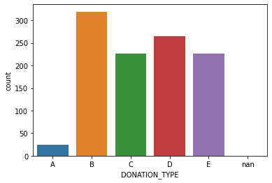

```python
sns.countplot(x='DONATION_TYPE', data=k1)
```

```python
k1.describe()
```

|  | TARGET_D | DONOR_AGE | MEDIAN_HOME_VALUE | MEDIAN_HOUSEHOLD_INCOME | PCT_OWNER_OCCUPIED | PCT_MILITARY | PCT_VETERANS | RECENT_RESPONSE_PROP | RECENT_AVG_GIFT_AMT | RECENT_CARD_RESPONSE_PROP | RECENT_AVG_CARD_GIFT_AMT | RECENT_CARD_RESPONSE_COUNT | MONTHS_SINCE_LAST_PROM_RESP | LIFETIME_AVG_GIFT_AMT | LAST_GIFT_AMT | CARD_PROM_12 | MONTHS_SINCE_LAST_GIFT | MONTHS_SINCE_FIRST_GIFT | FILE_CARD_GIFT | K-MEANS |
| --- | --- | --- | --- | --- | --- | --- | --- | --- | --- | --- | --- | --- | --- | --- | --- | --- | --- | --- | --- | --- |
| count | 1062.000000 | 1062.000000 | 1062.000000 | 1062.000000 | 1062.000000 | 1062.000000 | 1062.000000 | 1062.000000 | 1062.000000 | 1062.000000 | 1062.000000 | 1062.000000 | 1062.000000 | 1062.000000 | 1062.000000 | 1062.000000 | 1062.000000 | 1062.000000 | 1062.000000 | 1062.0 |
| mean | 16.278126 | 60.887006 | 1182.768362 | 379.622411 | 74.271186 | 1.042373 | 32.075330 | 0.198550 | 14.391704 | 0.242149 | 11.233418 | 1.974576 | 18.641243 | 11.990960 | 15.638889 | 5.522599 | 17.500000 | 76.216573 | 6.040490 | 0.0 |
| std | 14.251671 | 15.374019 | 1011.998900 | 171.720653 | 18.973465 | 4.661501 | 11.029392 | 0.110077 | 10.744142 | 0.176849 | 9.581656 | 1.614121 | 3.361129 | 9.059971 | 13.375029 | 1.291222 | 4.379446 | 37.111013 | 4.582397 | 0.0 |
| min | 2.000000 | 4.000000 | 128.000000 | 0.000000 | 0.000000 | 0.000000 | 0.000000 | 0.000000 | 0.000000 | 0.000000 | 0.000000 | 0.000000 | -11.000000 | 2.460000 | 0.000000 | 2.000000 | 4.000000 | 15.000000 | 0.000000 | 0.0 |
| 25% | 10.000000 | 50.000000 | 575.000000 | 260.250000 | 66.000000 | 0.000000 | 26.000000 | 0.111000 | 9.000000 | 0.111000 | 5.000000 | 1.000000 | 17.000000 | 7.447500 | 10.000000 | 5.000000 | 16.000000 | 41.000000 | 2.000000 | 0.0 |
| 50% | 15.000000 | 61.000000 | 827.000000 | 345.000000 | 79.000000 | 0.000000 | 32.000000 | 0.176000 | 12.750000 | 0.222000 | 10.000000 | 2.000000 | 18.000000 | 10.270000 | 15.000000 | 6.000000 | 18.000000 | 77.000000 | 5.000000 | 0.0 |
| 75% | 20.000000 | 74.000000 | 1393.000000 | 465.000000 | 88.000000 | 0.000000 | 39.000000 | 0.266000 | 17.500000 | 0.364000 | 15.000000 | 3.000000 | 20.000000 | 14.787500 | 20.000000 | 6.000000 | 19.000000 | 110.750000 | 9.000000 | 0.0 |
| max | 200.000000 | 87.000000 | 5965.000000 | 1500.000000 | 99.000000 | 87.000000 | 76.000000 | 0.650000 | 200.000000 | 0.833000 | 100.000000 | 9.000000 | 32.000000 | 200.000000 | 250.000000 | 11.000000 | 27.000000 | 230.000000 | 25.000000 | 0.0 |

```python
k1.describe(include=['object', 'category'])
```

|  | IN_HOUSE | URBANICITY | SES | HOME_OWNER | DONOR_GENDER | PUBLISHED_PHONE | MOR_HIT_RATE | RECENCY_STATUS_96NK | FREQUENCY_STATUS_97NK | DONATION_TYPE |
| --- | --- | --- | --- | --- | --- | --- | --- | --- | --- | --- |
| count | 1062 | 1062 | 1062 | 1062 | 1062 | 1062 | 1062 | 1062 | 1062 | 1062 |
| unique | 2 | 5 | 4 | 2 | 3 | 2 | 2 | 6 | 4 | 5 |
| top | 0 | S | 2 | H | M | 1 | 1 | A | 1 | B |
| freq | 954 | 316 | 538 | 908 | 1055 | 908 | 914 | 647 | 422 | 319 |

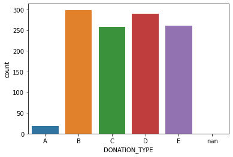

```python
sns.countplot(x='DONATION_TYPE', data=k2)
```

```python
k2.describe()
```

|  | TARGET_D | DONOR_AGE | MEDIAN_HOME_VALUE | MEDIAN_HOUSEHOLD_INCOME | PCT_OWNER_OCCUPIED | PCT_MILITARY | PCT_VETERANS | RECENT_RESPONSE_PROP | RECENT_AVG_GIFT_AMT | RECENT_CARD_RESPONSE_PROP | RECENT_AVG_CARD_GIFT_AMT | RECENT_CARD_RESPONSE_COUNT | MONTHS_SINCE_LAST_PROM_RESP | LIFETIME_AVG_GIFT_AMT | LAST_GIFT_AMT | CARD_PROM_12 | MONTHS_SINCE_LAST_GIFT | MONTHS_SINCE_FIRST_GIFT | FILE_CARD_GIFT | K-MEANS |
| --- | --- | --- | --- | --- | --- | --- | --- | --- | --- | --- | --- | --- | --- | --- | --- | --- | --- | --- | --- | --- |
| count | 1126.00000 | 1126.000000 | 1126.000000 | 1126.000000 | 1126.000000 | 1126.000000 | 1126.000000 | 1126.000000 | 1126.000000 | 1126.000000 | 1126.000000 | 1126.000000 | 1126.000000 | 1126.000000 | 1126.000000 | 1126.000000 | 1126.000000 | 1126.000000 | 1126.000000 | 1126.0 |
| mean | 14.81032 | 61.022202 | 1094.024867 | 345.659858 | 69.814387 | 0.979574 | 31.823268 | 0.209310 | 13.516066 | 0.261249 | 11.321661 | 2.089698 | 18.626110 | 11.182700 | 14.522869 | 5.476909 | 17.675844 | 75.977798 | 6.361456 | 1.0 |
| std | 9.68889 | 14.881471 | 955.560773 | 156.069126 | 20.511768 | 3.833945 | 10.490624 | 0.114614 | 9.230841 | 0.185231 | 10.884896 | 1.656218 | 3.124326 | 7.902688 | 11.548072 | 1.329628 | 4.089953 | 38.429369 | 4.997767 | 0.0 |
| min | 1.00000 | 6.000000 | 139.000000 | 0.000000 | 0.000000 | 0.000000 | 0.000000 | 0.000000 | 0.000000 | 0.000000 | 0.000000 | 0.000000 | 8.000000 | 2.260000 | 0.000000 | 2.000000 | 4.000000 | 15.000000 | 0.000000 | 1.0 |
| 25% | 10.00000 | 51.000000 | 548.250000 | 242.250000 | 58.000000 | 0.000000 | 25.250000 | 0.125000 | 8.290000 | 0.125000 | 5.250000 | 1.000000 | 16.000000 | 6.920000 | 10.000000 | 5.000000 | 16.000000 | 41.000000 | 2.000000 | 1.0 |
| 50% | 13.00000 | 61.000000 | 759.500000 | 321.000000 | 75.000000 | 0.000000 | 32.000000 | 0.190000 | 12.500000 | 0.250000 | 10.000000 | 2.000000 | 18.000000 | 9.925000 | 14.000000 | 6.000000 | 18.000000 | 76.000000 | 5.000000 | 1.0 |
| 75% | 20.00000 | 73.000000 | 1222.000000 | 417.000000 | 85.000000 | 0.000000 | 38.000000 | 0.273000 | 16.000000 | 0.375000 | 15.000000 | 3.000000 | 21.000000 | 13.330000 | 18.000000 | 6.000000 | 20.000000 | 113.000000 | 9.000000 | 1.0 |
| max | 100.00000 | 87.000000 | 5946.000000 | 1500.000000 | 99.000000 | 60.000000 | 76.000000 | 0.750000 | 116.670000 | 1.000000 | 200.000000 | 8.000000 | 31.000000 | 122.170000 | 219.000000 | 17.000000 | 27.000000 | 260.000000 | 26.000000 | 1.0 |

```python
k2.describe(include=['object', 'category'])
```

|  | IN_HOUSE | URBANICITY | SES | HOME_OWNER | DONOR_GENDER | PUBLISHED_PHONE | MOR_HIT_RATE | RECENCY_STATUS_96NK | FREQUENCY_STATUS_97NK | DONATION_TYPE |
| --- | --- | --- | --- | --- | --- | --- | --- | --- | --- | --- |
| count | 1126 | 1126 | 1126 | 1126 | 1126 | 1126 | 1126 | 1126 | 1126 | 1126 |
| unique | 2 | 5 | 4 | 2 | 2 | 2 | 2 | 6 | 4 | 5 |
| top | 0 | C | 2 | H | F | 1 | 1 | A | 1 | B |
| freq | 1030 | 332 | 560 | 941 | 1097 | 990 | 990 | 666 | 414 | 299 |

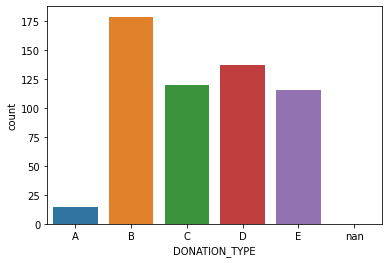

```python
sns.countplot(x='DONATION_TYPE', data=k3)
```

```python
k3.describe()
```

|  | TARGET_D | DONOR_AGE | MEDIAN_HOME_VALUE | MEDIAN_HOUSEHOLD_INCOME | PCT_OWNER_OCCUPIED | PCT_MILITARY | PCT_VETERANS | RECENT_RESPONSE_PROP | RECENT_AVG_GIFT_AMT | RECENT_CARD_RESPONSE_PROP | RECENT_AVG_CARD_GIFT_AMT | RECENT_CARD_RESPONSE_COUNT | MONTHS_SINCE_LAST_PROM_RESP | LIFETIME_AVG_GIFT_AMT | LAST_GIFT_AMT | CARD_PROM_12 | MONTHS_SINCE_LAST_GIFT | MONTHS_SINCE_FIRST_GIFT | FILE_CARD_GIFT | K-MEANS |
| --- | --- | --- | --- | --- | --- | --- | --- | --- | --- | --- | --- | --- | --- | --- | --- | --- | --- | --- | --- | --- |
| count | 567.000000 | 567.000000 | 567.000000 | 567.000000 | 567.000000 | 567.000000 | 567.000000 | 567.000000 | 567.000000 | 567.000000 | 567.000000 | 567.000000 | 567.000000 | 567.000000 | 567.000000 | 567.000000 | 567.000000 | 567.000000 | 567.000000 | 567.0 |
| mean | 16.373827 | 58.172840 | 1613.209877 | 435.409171 | 70.511464 | 0.982363 | 26.931217 | 0.212616 | 15.297619 | 0.265617 | 12.840406 | 2.047619 | 18.707231 | 12.679700 | 15.832469 | 5.492063 | 17.312169 | 71.084656 | 5.707231 | 2.0 |
| std | 12.687386 | 14.033596 | 1276.059791 | 203.680590 | 22.521434 | 2.909052 | 13.532732 | 0.128637 | 11.088184 | 0.195747 | 11.614403 | 1.625609 | 3.361442 | 8.598328 | 11.781538 | 1.552221 | 4.597154 | 36.560225 | 4.645261 | 0.0 |
| min | 2.000000 | 7.000000 | 221.000000 | 0.000000 | 0.000000 | 0.000000 | 0.000000 | 0.000000 | 0.000000 | 0.000000 | 0.000000 | 0.000000 | 9.000000 | 3.060000 | 0.000000 | 1.000000 | 4.000000 | 15.000000 | 0.000000 | 2.0 |
| 25% | 10.000000 | 49.000000 | 747.000000 | 306.000000 | 59.000000 | 0.000000 | 22.000000 | 0.125000 | 9.550000 | 0.118000 | 6.635000 | 1.000000 | 16.000000 | 7.900000 | 10.000000 | 5.000000 | 16.000000 | 41.000000 | 2.000000 | 2.0 |
| 50% | 15.000000 | 60.000000 | 1086.000000 | 398.000000 | 76.000000 | 0.000000 | 29.000000 | 0.188000 | 13.250000 | 0.250000 | 11.000000 | 2.000000 | 18.000000 | 10.680000 | 15.000000 | 6.000000 | 18.000000 | 68.000000 | 5.000000 | 2.0 |
| 75% | 20.000000 | 65.000000 | 2047.000000 | 512.000000 | 88.000000 | 0.000000 | 36.000000 | 0.273000 | 18.000000 | 0.364000 | 16.000000 | 3.000000 | 20.500000 | 15.000000 | 20.000000 | 6.000000 | 19.000000 | 105.000000 | 8.000000 | 2.0 |
| max | 102.000000 | 87.000000 | 5975.000000 | 1500.000000 | 99.000000 | 23.000000 | 66.000000 | 1.000000 | 100.000000 | 1.000000 | 100.000000 | 9.000000 | 35.000000 | 100.000000 | 133.000000 | 13.000000 | 26.000000 | 187.000000 | 41.000000 | 2.0 |

```python
k3.describe(include=['object', 'category'])
```

|  | IN_HOUSE | URBANICITY | SES | HOME_OWNER | DONOR_GENDER | PUBLISHED_PHONE | MOR_HIT_RATE | RECENCY_STATUS_96NK | FREQUENCY_STATUS_97NK | DONATION_TYPE |
| --- | --- | --- | --- | --- | --- | --- | --- | --- | --- | --- |
| count | 567 | 567 | 567 | 567 | 567 | 567 | 567 | 567 | 567 | 567 |
| unique | 2 | 1 | 3 | 2 | 2 | 2 | 2 | 6 | 4 | 5 |
| top | 0 | S | 1 | U | F | 0 | 0 | A | 1 | B |
| freq | 499 | 567 | 272 | 304 | 490 | 451 | 467 | 340 | 217 | 179 |

Even though k-means did not cleanly separate the donors by donation type, we can identify the cluster that includes the highest average donation amount and take a deeper look at its elements to get a better understanding of the most profile of the most generous donors.

- **1:** All elements live in a suburban environment;
- **2:** Most donors don't have their phone number published;
- **3:** Most donors never responded to other charities' solicitations;
- **4:** Most donors never donated to the organization's in-house program;
- **5:** This group's elements live in neighborhoods with low % of military (<1%) but over 25% of veterans, where the vast majority of houses are owner-occupied.

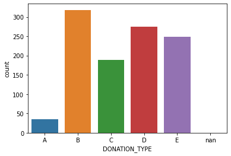

```python
sns.countplot(x='DONATION_TYPE', data=k4)
```

```python
k4.describe()
```

|  | TARGET_D | DONOR_AGE | MEDIAN_HOME_VALUE | MEDIAN_HOUSEHOLD_INCOME | PCT_OWNER_OCCUPIED | PCT_MILITARY | PCT_VETERANS | RECENT_RESPONSE_PROP | RECENT_AVG_GIFT_AMT | RECENT_CARD_RESPONSE_PROP | RECENT_AVG_CARD_GIFT_AMT | RECENT_CARD_RESPONSE_COUNT | MONTHS_SINCE_LAST_PROM_RESP | LIFETIME_AVG_GIFT_AMT | LAST_GIFT_AMT | CARD_PROM_12 | MONTHS_SINCE_LAST_GIFT | MONTHS_SINCE_FIRST_GIFT | FILE_CARD_GIFT | K-MEANS |
| --- | --- | --- | --- | --- | --- | --- | --- | --- | --- | --- | --- | --- | --- | --- | --- | --- | --- | --- | --- | --- |
| count | 1066.000000 | 1066.000000 | 1066.000000 | 1066.000000 | 1066.000000 | 1066.000000 | 1066.000000 | 1066.000000 | 1066.000000 | 1066.000000 | 1066.000000 | 1066.000000 | 1066.000000 | 1066.000000 | 1066.000000 | 1066.000000 | 1066.000000 | 1066.000000 | 1066.000000 | 1066.0 |
| mean | 16.192495 | 59.993433 | 1140.476548 | 340.240150 | 69.798311 | 0.961538 | 30.395872 | 0.220113 | 14.164784 | 0.273286 | 11.260938 | 2.072233 | 18.681989 | 12.106614 | 15.292120 | 5.392120 | 17.646341 | 71.931520 | 6.085366 | 3.0 |
| std | 13.574083 | 12.489280 | 1052.895138 | 183.324829 | 22.282599 | 5.018222 | 11.822591 | 0.132588 | 8.897517 | 0.207503 | 9.026000 | 1.672040 | 3.092197 | 7.446421 | 10.599769 | 1.533382 | 4.139773 | 37.490957 | 4.966482 | 0.0 |
| min | 1.000000 | 7.000000 | 150.000000 | 0.000000 | 0.000000 | 0.000000 | 0.000000 | 0.000000 | 0.000000 | 0.000000 | 0.000000 | 0.000000 | 9.000000 | 2.580000 | 0.000000 | 0.000000 | 4.000000 | 15.000000 | 0.000000 | 3.0 |
| 25% | 10.000000 | 55.000000 | 514.250000 | 225.000000 | 62.000000 | 0.000000 | 25.000000 | 0.125000 | 8.500000 | 0.111000 | 5.000000 | 1.000000 | 17.000000 | 7.207500 | 10.000000 | 5.000000 | 16.000000 | 36.000000 | 2.000000 | 3.0 |
| 50% | 13.000000 | 60.000000 | 747.000000 | 296.000000 | 76.000000 | 0.000000 | 31.000000 | 0.195000 | 12.500000 | 0.250000 | 10.000000 | 2.000000 | 18.000000 | 10.140000 | 14.000000 | 6.000000 | 18.000000 | 69.000000 | 5.000000 | 3.0 |
| 75% | 20.000000 | 67.000000 | 1284.250000 | 411.750000 | 85.000000 | 0.000000 | 37.000000 | 0.286000 | 18.000000 | 0.400000 | 15.000000 | 3.000000 | 21.000000 | 15.000000 | 20.000000 | 6.000000 | 19.750000 | 105.000000 | 9.000000 | 3.0 |
| max | 200.000000 | 87.000000 | 5982.000000 | 1500.000000 | 99.000000 | 96.000000 | 79.000000 | 0.875000 | 100.000000 | 1.000000 | 73.330000 | 8.000000 | 33.000000 | 57.500000 | 100.000000 | 15.000000 | 27.000000 | 143.000000 | 28.000000 | 3.0 |

```python
k4.describe(include=['object', 'category'])
```

|  | IN_HOUSE | URBANICITY | SES | HOME_OWNER | DONOR_GENDER | PUBLISHED_PHONE | MOR_HIT_RATE | RECENCY_STATUS_96NK | FREQUENCY_STATUS_97NK | DONATION_TYPE |
| --- | --- | --- | --- | --- | --- | --- | --- | --- | --- | --- |
| count | 1066 | 1066 | 1066 | 1066 | 1066 | 1066 | 1066 | 1066 | 1066 | 1066 |
| unique | 2 | 5 | 4 | 2 | 2 | 2 | 2 | 6 | 4 | 5 |
| top | 0 | R | 2 | U | M | 0 | 0 | A | 1 | B |
| freq | 967 | 296 | 545 | 750 | 907 | 852 | 1020 | 595 | 391 | 318 |

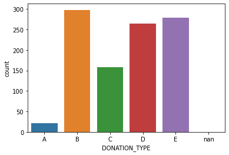

```python
sns.countplot(x='DONATION_TYPE', data=k5)
```

```python
k5.describe()
```

|  | TARGET_D | DONOR_AGE | MEDIAN_HOME_VALUE | MEDIAN_HOUSEHOLD_INCOME | PCT_OWNER_OCCUPIED | PCT_MILITARY | PCT_VETERANS | RECENT_RESPONSE_PROP | RECENT_AVG_GIFT_AMT | RECENT_CARD_RESPONSE_PROP | RECENT_AVG_CARD_GIFT_AMT | RECENT_CARD_RESPONSE_COUNT | MONTHS_SINCE_LAST_PROM_RESP | LIFETIME_AVG_GIFT_AMT | LAST_GIFT_AMT | CARD_PROM_12 | MONTHS_SINCE_LAST_GIFT | MONTHS_SINCE_FIRST_GIFT | FILE_CARD_GIFT | K-MEANS |
| --- | --- | --- | --- | --- | --- | --- | --- | --- | --- | --- | --- | --- | --- | --- | --- | --- | --- | --- | --- | --- |
| count | 1022.000000 | 1022.000000 | 1022.000000 | 1022.000000 | 1022.000000 | 1022.000000 | 1022.000000 | 1022.000000 | 1022.000000 | 1022.000000 | 1022.000000 | 1022.000000 | 1022.000000 | 1022.000000 | 1022.000000 | 1022.000000 | 1022.000000 | 1022.000000 | 1022.000000 | 1022.0 |
| mean | 14.833415 | 58.897260 | 1026.193738 | 300.215264 | 67.067515 | 1.018591 | 30.670254 | 0.227165 | 13.473581 | 0.276092 | 10.852250 | 2.139922 | 18.573386 | 11.648875 | 14.895900 | 5.393346 | 17.558708 | 72.392368 | 6.181996 | 4.0 |
| std | 11.667276 | 12.213022 | 858.136078 | 127.240665 | 21.627202 | 5.447519 | 11.267988 | 0.134588 | 8.713257 | 0.200994 | 8.414479 | 1.725817 | 3.441123 | 15.311314 | 18.431937 | 1.498898 | 4.242869 | 37.152802 | 5.129293 | 0.0 |
| min | 1.000000 | 7.000000 | 150.000000 | 0.000000 | 0.000000 | 0.000000 | 0.000000 | 0.000000 | 0.000000 | 0.000000 | 0.000000 | 0.000000 | -9.000000 | 2.320000 | 0.000000 | 1.000000 | 4.000000 | 15.000000 | 0.000000 | 4.0 |
| 25% | 8.000000 | 53.250000 | 481.000000 | 211.000000 | 57.000000 | 0.000000 | 24.000000 | 0.136000 | 8.000000 | 0.125000 | 5.147500 | 1.000000 | 16.000000 | 6.702500 | 10.000000 | 5.000000 | 16.000000 | 40.000000 | 2.000000 | 4.0 |
| 50% | 11.000000 | 60.000000 | 730.500000 | 276.500000 | 74.000000 | 0.000000 | 31.000000 | 0.200000 | 12.000000 | 0.250000 | 10.000000 | 2.000000 | 18.000000 | 9.720000 | 14.000000 | 6.000000 | 18.000000 | 69.500000 | 5.000000 | 4.0 |
| 75% | 20.000000 | 64.000000 | 1184.750000 | 365.000000 | 82.000000 | 0.000000 | 37.000000 | 0.300000 | 17.330000 | 0.400000 | 15.000000 | 3.000000 | 20.000000 | 14.000000 | 20.000000 | 6.000000 | 19.000000 | 105.750000 | 9.000000 | 4.0 |
| max | 200.000000 | 87.000000 | 5708.000000 | 937.000000 | 99.000000 | 93.000000 | 76.000000 | 1.000000 | 150.000000 | 1.000000 | 87.500000 | 9.000000 | 33.000000 | 450.000000 | 450.000000 | 17.000000 | 27.000000 | 160.000000 | 29.000000 | 4.0 |

```python
k5.describe(include=['object', 'category'])
```

|  | IN_HOUSE | URBANICITY | SES | HOME_OWNER | DONOR_GENDER | PUBLISHED_PHONE | MOR_HIT_RATE | RECENCY_STATUS_96NK | FREQUENCY_STATUS_97NK | DONATION_TYPE |
| --- | --- | --- | --- | --- | --- | --- | --- | --- | --- | --- |
| count | 1022 | 1022 | 1022 | 1022 | 1022 | 1022 | 1022 | 1022 | 1022 | 1022 |
| unique | 2 | 4 | 4 | 2 | 1 | 2 | 2 | 6 | 4 | 5 |
| top | 0 | R | 2 | U | F | 0 | 0 | A | 1 | B |
| freq | 949 | 313 | 549 | 742 | 1022 | 853 | 982 | 546 | 350 | 298 |

However, we think that k-means is not the best methods for our goals for 2 reasons:

- there are 2 other clusters with similar average donation amount.
- the results are different each time the algorithm is ran, even when random_state=0 is defined.

These observations seem to indicate that our data is not suited to k-means. Let's see if hierarchical clustering gives us better results.

### Hierarchical

```python
activeDonors3['HIERARCH']=hca.labels_
```

```python
hc1 = activeDonors3[activeDonors3['HIERARCH']==0]
hc2 = activeDonors3[activeDonors3['HIERARCH']==1]
hc3 = activeDonors3[activeDonors3['HIERARCH']==2]
hc4 = activeDonors3[activeDonors3['HIERARCH']==3]
hc5 = activeDonors3[activeDonors3['HIERARCH']==4]
```

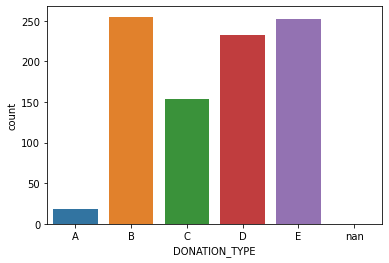

```python
sns.countplot(x='DONATION_TYPE', data=hc1)
```

```python
hc1.describe()
```

|  | TARGET_D | DONOR_AGE | MEDIAN_HOME_VALUE | MEDIAN_HOUSEHOLD_INCOME | PCT_OWNER_OCCUPIED | PCT_MILITARY | PCT_VETERANS | RECENT_RESPONSE_PROP | RECENT_AVG_GIFT_AMT | RECENT_CARD_RESPONSE_PROP | RECENT_AVG_CARD_GIFT_AMT | RECENT_CARD_RESPONSE_COUNT | MONTHS_SINCE_LAST_PROM_RESP | LIFETIME_AVG_GIFT_AMT | LAST_GIFT_AMT | CARD_PROM_12 | MONTHS_SINCE_LAST_GIFT | MONTHS_SINCE_FIRST_GIFT | FILE_CARD_GIFT | K-MEANS | HIERARCH |
| --- | --- | --- | --- | --- | --- | --- | --- | --- | --- | --- | --- | --- | --- | --- | --- | --- | --- | --- | --- | --- | --- |
| count | 911.000000 | 911.000000 | 911.000000 | 911.000000 | 911.000000 | 911.000000 | 911.000000 | 911.000000 | 911.000000 | 911.000000 | 911.000000 | 911.000000 | 911.000000 | 911.000000 | 911.000000 | 911.000000 | 911.000000 | 911.000000 | 911.000000 | 911.000000 | 911.0 |
| mean | 14.968946 | 60.479693 | 1313.568606 | 346.477497 | 65.530187 | 0.716795 | 28.693743 | 0.215252 | 13.346553 | 0.265036 | 11.022821 | 2.127333 | 18.538968 | 11.341240 | 14.357585 | 5.423710 | 17.568606 | 77.294182 | 6.618002 | 2.745335 | 0.0 |
| std | 12.214631 | 12.500610 | 1132.079791 | 185.443754 | 24.377952 | 2.836755 | 12.095570 | 0.111428 | 8.808476 | 0.181198 | 8.878416 | 1.583996 | 3.419139 | 7.783582 | 11.450944 | 1.576771 | 4.236869 | 37.116348 | 4.963500 | 1.210266 | 0.0 |
| min | 2.000000 | 7.000000 | 139.000000 | 0.000000 | 0.000000 | 0.000000 | 0.000000 | 0.000000 | 0.000000 | 0.000000 | 0.000000 | 0.000000 | -9.000000 | 2.360000 | 2.000000 | 1.000000 | 4.000000 | 15.000000 | 0.000000 | 0.000000 | 0.0 |
| 25% | 8.000000 | 55.000000 | 567.500000 | 220.000000 | 51.000000 | 0.000000 | 23.000000 | 0.143000 | 7.635000 | 0.125000 | 5.585000 | 1.000000 | 16.000000 | 6.625000 | 9.000000 | 5.000000 | 16.000000 | 43.500000 | 3.000000 | 2.000000 | 0.0 |
| 50% | 12.000000 | 60.000000 | 876.000000 | 306.000000 | 72.000000 | 0.000000 | 29.000000 | 0.200000 | 11.430000 | 0.250000 | 10.000000 | 2.000000 | 18.000000 | 9.670000 | 12.000000 | 6.000000 | 18.000000 | 76.000000 | 5.000000 | 3.000000 | 0.0 |
| 75% | 20.000000 | 68.000000 | 1712.000000 | 425.000000 | 84.000000 | 0.000000 | 36.000000 | 0.273000 | 16.000000 | 0.375000 | 15.000000 | 3.000000 | 20.000000 | 14.050000 | 20.000000 | 6.000000 | 19.000000 | 113.000000 | 10.000000 | 4.000000 | 0.0 |
| max | 200.000000 | 87.000000 | 5975.000000 | 1500.000000 | 99.000000 | 47.000000 | 76.000000 | 1.000000 | 100.000000 | 1.000000 | 87.500000 | 9.000000 | 35.000000 | 122.170000 | 219.000000 | 17.000000 | 27.000000 | 160.000000 | 26.000000 | 4.000000 | 0.0 |

```python
hc1.describe(include=['object', 'category'])
```

|  | IN_HOUSE | URBANICITY | SES | HOME_OWNER | DONOR_GENDER | PUBLISHED_PHONE | MOR_HIT_RATE | RECENCY_STATUS_96NK | FREQUENCY_STATUS_97NK | DONATION_TYPE |
| --- | --- | --- | --- | --- | --- | --- | --- | --- | --- | --- |
| count | 911 | 911 | 911 | 911 | 911 | 911 | 911 | 911 | 911 | 911 |
| unique | 2 | 5 | 4 | 2 | 3 | 2 | 2 | 6 | 4 | 5 |
| top | 0 | S | 1 | U | F | 0 | 0 | A | 3 | B |
| freq | 836 | 275 | 328 | 564 | 634 | 635 | 710 | 471 | 448 | 255 |

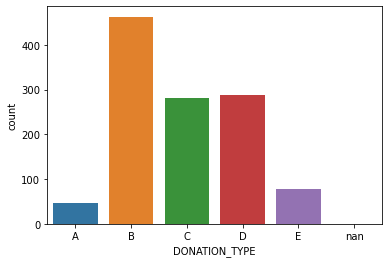

```python
sns.countplot(x='DONATION_TYPE', data=hc2)
```

```python
hc2.describe()
```

|  | TARGET_D | DONOR_AGE | MEDIAN_HOME_VALUE | MEDIAN_HOUSEHOLD_INCOME | PCT_OWNER_OCCUPIED | PCT_MILITARY | PCT_VETERANS | RECENT_RESPONSE_PROP | RECENT_AVG_GIFT_AMT | RECENT_CARD_RESPONSE_PROP | RECENT_AVG_CARD_GIFT_AMT | RECENT_CARD_RESPONSE_COUNT | MONTHS_SINCE_LAST_PROM_RESP | LIFETIME_AVG_GIFT_AMT | LAST_GIFT_AMT | CARD_PROM_12 | MONTHS_SINCE_LAST_GIFT | MONTHS_SINCE_FIRST_GIFT | FILE_CARD_GIFT | K-MEANS | HIERARCH |
| --- | --- | --- | --- | --- | --- | --- | --- | --- | --- | --- | --- | --- | --- | --- | --- | --- | --- | --- | --- | --- | --- |
| count | 1158.000000 | 1158.000000 | 1158.000000 | 1158.000000 | 1158.000000 | 1158.000000 | 1158.000000 | 1158.000000 | 1158.000000 | 1158.000000 | 1158.000000 | 1158.000000 | 1158.000000 | 1158.000000 | 1158.000000 | 1158.000000 | 1158.000000 | 1158.000000 | 1158.000000 | 1158.000000 | 1158.0 |
| mean | 19.425794 | 59.580311 | 1343.198618 | 393.155440 | 72.214162 | 1.044041 | 30.887737 | 0.150797 | 17.170492 | 0.187041 | 12.907219 | 1.364421 | 19.283247 | 14.125674 | 18.598014 | 5.424870 | 18.054404 | 71.436960 | 4.874784 | 1.195164 | 1.0 |
| std | 14.955617 | 14.655067 | 1184.002795 | 199.923637 | 21.040663 | 4.781912 | 11.721465 | 0.074501 | 11.172750 | 0.149536 | 10.890552 | 1.116473 | 3.393152 | 9.342987 | 13.739524 | 1.335948 | 4.505022 | 37.465639 | 4.017125 | 1.456928 | 0.0 |
| min | 2.000000 | 7.000000 | 128.000000 | 0.000000 | 0.000000 | 0.000000 | 0.000000 | 0.000000 | 0.000000 | 0.000000 | 0.000000 | 0.000000 | 6.000000 | 3.270000 | 0.000000 | 2.000000 | 4.000000 | 15.000000 | 0.000000 | 0.000000 | 1.0 |
| 25% | 10.000000 | 50.000000 | 605.000000 | 258.000000 | 64.000000 | 0.000000 | 24.000000 | 0.100000 | 11.670000 | 0.091000 | 5.702500 | 1.000000 | 17.000000 | 9.500000 | 12.000000 | 5.000000 | 16.000000 | 33.000000 | 2.000000 | 0.000000 | 1.0 |
| 50% | 16.000000 | 60.000000 | 886.500000 | 354.500000 | 78.000000 | 0.000000 | 31.000000 | 0.143000 | 15.000000 | 0.167000 | 12.500000 | 1.000000 | 18.000000 | 12.330000 | 15.000000 | 6.000000 | 18.000000 | 74.000000 | 4.000000 | 0.000000 | 1.0 |
| 75% | 23.000000 | 72.000000 | 1565.750000 | 481.000000 | 88.000000 | 0.000000 | 38.000000 | 0.200000 | 20.000000 | 0.273000 | 18.000000 | 2.000000 | 21.000000 | 16.000000 | 20.000000 | 6.000000 | 21.000000 | 105.000000 | 7.000000 | 3.000000 | 1.0 |
| max | 200.000000 | 87.000000 | 5982.000000 | 1500.000000 | 99.000000 | 96.000000 | 79.000000 | 0.571000 | 200.000000 | 0.667000 | 100.000000 | 6.000000 | 33.000000 | 200.000000 | 250.000000 | 15.000000 | 27.000000 | 170.000000 | 22.000000 | 3.000000 | 1.0 |

```python
hc2.describe(include=['object', 'category'])
```

|  | IN_HOUSE | URBANICITY | SES | HOME_OWNER | DONOR_GENDER | PUBLISHED_PHONE | MOR_HIT_RATE | RECENCY_STATUS_96NK | FREQUENCY_STATUS_97NK | DONATION_TYPE |
| --- | --- | --- | --- | --- | --- | --- | --- | --- | --- | --- |
| count | 1158 | 1158 | 1158 | 1158 | 1158 | 1158 | 1158 | 1158 | 1158 | 1158 |
| unique | 2 | 5 | 4 | 2 | 3 | 2 | 2 | 6 | 4 | 5 |
| top | 0 | S | 1 | H | M | 1 | 1 | A | 1 | B |
| freq | 1022 | 386 | 483 | 774 | 1126 | 671 | 624 | 793 | 634 | 463 |

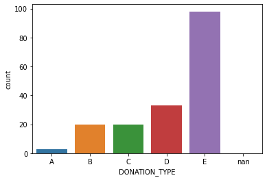

```python
sns.countplot(x='DONATION_TYPE', data=hc3)
```

```python
hc3.describe()
```

|  | TARGET_D | DONOR_AGE | MEDIAN_HOME_VALUE | MEDIAN_HOUSEHOLD_INCOME | PCT_OWNER_OCCUPIED | PCT_MILITARY | PCT_VETERANS | RECENT_RESPONSE_PROP | RECENT_AVG_GIFT_AMT | RECENT_CARD_RESPONSE_PROP | RECENT_AVG_CARD_GIFT_AMT | RECENT_CARD_RESPONSE_COUNT | MONTHS_SINCE_LAST_PROM_RESP | LIFETIME_AVG_GIFT_AMT | LAST_GIFT_AMT | CARD_PROM_12 | MONTHS_SINCE_LAST_GIFT | MONTHS_SINCE_FIRST_GIFT | FILE_CARD_GIFT | K-MEANS | HIERARCH |
| --- | --- | --- | --- | --- | --- | --- | --- | --- | --- | --- | --- | --- | --- | --- | --- | --- | --- | --- | --- | --- | --- |
| count | 174.000000 | 174.000000 | 174.000000 | 174.000000 | 174.000000 | 174.000000 | 174.000000 | 174.000000 | 174.000000 | 174.00000 | 174.000000 | 174.000000 | 174.000000 | 174.000000 | 174.000000 | 174.000000 | 174.000000 | 174.000000 | 174.000000 | 174.000000 | 174.0 |
| mean | 10.936782 | 60.063218 | 856.149425 | 301.310345 | 69.477011 | 1.511494 | 28.356322 | 0.407713 | 10.058218 | 0.51127 | 9.756609 | 4.132184 | 17.097701 | 8.693908 | 10.925287 | 5.178161 | 15.994253 | 81.132184 | 10.890805 | 3.074713 | 2.0 |
| std | 12.114651 | 12.929847 | 748.979136 | 126.563956 | 20.105417 | 9.643194 | 10.688416 | 0.152603 | 9.206489 | 0.22571 | 9.125670 | 2.028639 | 2.474540 | 6.651891 | 12.658253 | 2.002133 | 3.774721 | 36.949110 | 6.843809 | 1.148079 | 0.0 |
| min | 1.000000 | 7.000000 | 167.000000 | 0.000000 | 0.000000 | 0.000000 | 0.000000 | 0.100000 | 2.670000 | 0.00000 | 0.000000 | 0.000000 | 3.000000 | 2.450000 | 2.000000 | 0.000000 | 4.000000 | 15.000000 | 1.000000 | 1.000000 | 2.0 |
| 25% | 5.000000 | 60.000000 | 452.750000 | 210.250000 | 61.250000 | 0.000000 | 24.000000 | 0.308000 | 5.400000 | 0.36400 | 5.212500 | 3.000000 | 16.000000 | 4.910000 | 5.000000 | 4.000000 | 15.000000 | 45.000000 | 6.000000 | 2.000000 | 2.0 |
| 50% | 8.000000 | 60.000000 | 632.000000 | 272.500000 | 76.000000 | 0.000000 | 29.000000 | 0.389000 | 7.670000 | 0.50000 | 7.585000 | 4.000000 | 17.000000 | 6.785000 | 8.000000 | 6.000000 | 17.000000 | 81.000000 | 9.000000 | 4.000000 | 2.0 |
| 75% | 12.000000 | 62.750000 | 946.500000 | 365.500000 | 82.750000 | 0.750000 | 35.000000 | 0.494000 | 12.187500 | 0.63600 | 11.000000 | 5.000000 | 18.000000 | 10.285000 | 12.000000 | 6.000000 | 18.000000 | 121.000000 | 15.000000 | 4.000000 | 2.0 |
| max | 102.000000 | 87.000000 | 5727.000000 | 694.000000 | 97.000000 | 93.000000 | 62.000000 | 1.000000 | 99.830000 | 1.00000 | 99.800000 | 9.000000 | 25.000000 | 63.040000 | 133.000000 | 14.000000 | 24.000000 | 130.000000 | 41.000000 | 4.000000 | 2.0 |

```python
hc3.describe(include=['object', 'category'])
```

|  | IN_HOUSE | URBANICITY | SES | HOME_OWNER | DONOR_GENDER | PUBLISHED_PHONE | MOR_HIT_RATE | RECENCY_STATUS_96NK | FREQUENCY_STATUS_97NK | DONATION_TYPE |
| --- | --- | --- | --- | --- | --- | --- | --- | --- | --- | --- |
| count | 174 | 174 | 174 | 174 | 174 | 174 | 174 | 174 | 174 | 174 |
| unique | 2 | 5 | 3 | 2 | 3 | 2 | 2 | 3 | 4 | 5 |
| top | 0 | R | 2 | U | F | 0 | 0 | S | 4 | E |
| freq | 147 | 82 | 103 | 133 | 129 | 110 | 146 | 125 | 156 | 98 |

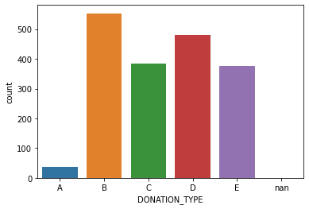

```python
sns.countplot(x='DONATION_TYPE', data=hc4)
```

```python
hc4.describe()
```

|  | TARGET_D | DONOR_AGE | MEDIAN_HOME_VALUE | MEDIAN_HOUSEHOLD_INCOME | PCT_OWNER_OCCUPIED | PCT_MILITARY | PCT_VETERANS | RECENT_RESPONSE_PROP | RECENT_AVG_GIFT_AMT | RECENT_CARD_RESPONSE_PROP | RECENT_AVG_CARD_GIFT_AMT | RECENT_CARD_RESPONSE_COUNT | MONTHS_SINCE_LAST_PROM_RESP | LIFETIME_AVG_GIFT_AMT | LAST_GIFT_AMT | CARD_PROM_12 | MONTHS_SINCE_LAST_GIFT | MONTHS_SINCE_FIRST_GIFT | FILE_CARD_GIFT | K-MEANS | HIERARCH |
| --- | --- | --- | --- | --- | --- | --- | --- | --- | --- | --- | --- | --- | --- | --- | --- | --- | --- | --- | --- | --- | --- |
| count | 1830.000000 | 1830.000000 | 1830.000000 | 1830.000000 | 1830.000000 | 1830.000000 | 1830.000000 | 1830.000000 | 1830.000000 | 1830.000000 | 1830.000000 | 1830.000000 | 1830.000000 | 1830.000000 | 1830.000000 | 1830.000000 | 1830.000000 | 1830.000000 | 1830.000000 | 1830.000000 | 1830.0 |
| mean | 15.524820 | 59.458470 | 1122.389617 | 350.110929 | 71.065574 | 1.067213 | 31.398361 | 0.202853 | 14.314377 | 0.251284 | 11.703519 | 1.913661 | 18.809290 | 12.015104 | 15.428749 | 5.432787 | 17.707104 | 71.882514 | 5.617486 | 2.121311 | 3.0 |
| std | 11.107048 | 14.217677 | 957.457780 | 154.677079 | 19.569200 | 4.344056 | 11.260390 | 0.117421 | 9.536289 | 0.185756 | 10.638005 | 1.553908 | 3.221243 | 12.728364 | 15.487838 | 1.359661 | 4.269298 | 37.822495 | 4.532866 | 1.316728 | 0.0 |
| min | 1.000000 | 6.000000 | 150.000000 | 0.000000 | 0.000000 | 0.000000 | 0.000000 | 0.000000 | 0.000000 | 0.000000 | 0.000000 | 0.000000 | 8.000000 | 2.260000 | 0.000000 | 1.000000 | 4.000000 | 15.000000 | 0.000000 | 1.000000 | 3.0 |
| 25% | 10.000000 | 50.000000 | 557.250000 | 246.000000 | 62.000000 | 0.000000 | 26.000000 | 0.111000 | 9.220000 | 0.111000 | 5.347500 | 1.000000 | 16.000000 | 7.442500 | 10.000000 | 5.000000 | 16.000000 | 39.000000 | 2.000000 | 1.000000 | 3.0 |
| 50% | 14.000000 | 60.000000 | 803.000000 | 321.500000 | 76.000000 | 0.000000 | 32.000000 | 0.182000 | 13.000000 | 0.222000 | 10.000000 | 2.000000 | 18.000000 | 10.170000 | 15.000000 | 6.000000 | 18.000000 | 68.000000 | 4.000000 | 1.000000 | 3.0 |
| 75% | 20.000000 | 70.000000 | 1259.750000 | 419.750000 | 85.000000 | 0.000000 | 38.000000 | 0.263000 | 17.500000 | 0.364000 | 15.500000 | 3.000000 | 21.000000 | 14.177500 | 20.000000 | 6.000000 | 20.000000 | 106.000000 | 8.000000 | 4.000000 | 3.0 |
| max | 200.000000 | 87.000000 | 5946.000000 | 1500.000000 | 99.000000 | 82.000000 | 76.000000 | 0.750000 | 150.000000 | 1.000000 | 200.000000 | 9.000000 | 33.000000 | 450.000000 | 450.000000 | 17.000000 | 27.000000 | 260.000000 | 26.000000 | 4.000000 | 3.0 |

```python
hc4.describe(include=['object', 'category'])
```

|  | IN_HOUSE | URBANICITY | SES | HOME_OWNER | DONOR_GENDER | PUBLISHED_PHONE | MOR_HIT_RATE | RECENCY_STATUS_96NK | FREQUENCY_STATUS_97NK | DONATION_TYPE |
| --- | --- | --- | --- | --- | --- | --- | --- | --- | --- | --- |
| count | 1830 | 1830 | 1830 | 1830 | 1830 | 1830 | 1830 | 1830 | 1830 | 1830 |
| unique | 2 | 5 | 4 | 2 | 2 | 2 | 2 | 6 | 4 | 5 |
| top | 0 | S | 2 | H | F | 1 | 0 | A | 1 | B |
| freq | 1673 | 521 | 1042 | 1139 | 1829 | 981 | 924 | 1150 | 748 | 553 |

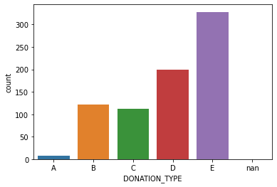

```python
sns.countplot(x='DONATION_TYPE', data=hc5)
```

```python
hc5.describe()
```

|  | TARGET_D | DONOR_AGE | MEDIAN_HOME_VALUE | MEDIAN_HOUSEHOLD_INCOME | PCT_OWNER_OCCUPIED | PCT_MILITARY | PCT_VETERANS | RECENT_RESPONSE_PROP | RECENT_AVG_GIFT_AMT | RECENT_CARD_RESPONSE_PROP | RECENT_AVG_CARD_GIFT_AMT | RECENT_CARD_RESPONSE_COUNT | MONTHS_SINCE_LAST_PROM_RESP | LIFETIME_AVG_GIFT_AMT | LAST_GIFT_AMT | CARD_PROM_12 | MONTHS_SINCE_LAST_GIFT | MONTHS_SINCE_FIRST_GIFT | FILE_CARD_GIFT | K-MEANS | HIERARCH |
| --- | --- | --- | --- | --- | --- | --- | --- | --- | --- | --- | --- | --- | --- | --- | --- | --- | --- | --- | --- | --- | --- |
| count | 770.000000 | 770.000000 | 770.000000 | 770.000000 | 770.000000 | 770.000000 | 770.000000 | 770.000000 | 770.000000 | 770.000000 | 770.000000 | 770.000000 | 770.000000 | 770.000000 | 770.000000 | 770.000000 | 770.000000 | 770.000000 | 770.000000 | 770.000000 | 770.0 |
| mean | 11.978571 | 61.236364 | 924.872727 | 317.816883 | 71.368831 | 0.980519 | 31.964935 | 0.287036 | 10.466117 | 0.348791 | 9.026377 | 2.945455 | 17.738961 | 9.268221 | 11.313506 | 5.636364 | 16.832468 | 76.183117 | 7.493506 | 1.615584 | 4.0 |
| std | 9.753156 | 13.659760 | 743.486920 | 138.585841 | 20.598498 | 4.700760 | 11.175748 | 0.126238 | 6.337677 | 0.198592 | 6.200018 | 1.828722 | 2.809174 | 5.745131 | 8.291556 | 1.392055 | 3.790239 | 36.749303 | 5.254074 | 1.505177 | 0.0 |
| min | 1.000000 | 4.000000 | 150.000000 | 0.000000 | 0.000000 | 0.000000 | 0.000000 | 0.000000 | 0.000000 | 0.000000 | 0.000000 | 0.000000 | -11.000000 | 2.460000 | 0.000000 | 1.000000 | 4.000000 | 15.000000 | 0.000000 | 0.000000 | 4.0 |
| 25% | 5.250000 | 55.000000 | 498.000000 | 228.000000 | 65.000000 | 0.000000 | 26.000000 | 0.200000 | 6.000000 | 0.200000 | 5.000000 | 2.000000 | 16.000000 | 5.552500 | 6.000000 | 5.000000 | 16.000000 | 41.000000 | 3.000000 | 0.000000 | 4.0 |
| 50% | 10.000000 | 60.000000 | 695.500000 | 292.000000 | 77.000000 | 0.000000 | 32.000000 | 0.278000 | 9.000000 | 0.364000 | 8.000000 | 3.000000 | 17.000000 | 7.875000 | 10.000000 | 6.000000 | 17.000000 | 75.500000 | 6.000000 | 3.000000 | 4.0 |
| 75% | 15.000000 | 71.000000 | 1025.250000 | 379.000000 | 85.000000 | 0.000000 | 38.000000 | 0.353000 | 12.700000 | 0.500000 | 11.000000 | 4.000000 | 19.000000 | 10.972500 | 15.000000 | 6.000000 | 18.000000 | 111.000000 | 10.000000 | 3.000000 | 4.0 |
| max | 100.000000 | 87.000000 | 5976.000000 | 1395.000000 | 99.000000 | 87.000000 | 78.000000 | 0.875000 | 50.000000 | 1.000000 | 50.000000 | 9.000000 | 30.000000 | 50.000000 | 100.000000 | 13.000000 | 26.000000 | 230.000000 | 28.000000 | 4.000000 | 4.0 |

```python
hc5.describe(include=['object', 'category'])
```

|  | IN_HOUSE | URBANICITY | SES | HOME_OWNER | DONOR_GENDER | PUBLISHED_PHONE | MOR_HIT_RATE | RECENCY_STATUS_96NK | FREQUENCY_STATUS_97NK | DONATION_TYPE |
| --- | --- | --- | --- | --- | --- | --- | --- | --- | --- | --- |
| count | 770 | 770 | 770 | 770 | 770 | 770 | 770 | 770 | 770 | 770 |
| unique | 2 | 5 | 4 | 2 | 2 | 2 | 2 | 5 | 4 | 5 |
| top | 0 | R | 2 | H | M | 1 | 0 | A | 4 | E |
| freq | 721 | 265 | 511 | 407 | 753 | 405 | 439 | 360 | 363 | 328 |

# 3. Final Comments, Limitations and Conclusions

**Regarding Task 1.1) Binary Classification:**

The dataset we were dealing with contained very few instances of the minority class (TARGET_B = 1) which represents the most important concept to be learned (that is, an individual is predicted to be a donor). For both multiclass and binary classification problems, various data engineering techniques are practiced to handle the imbalanced data.Due to time contraints and the fact that it could have been considered to be out of the scope of the class, we have chosen not to conduct any tecnique for the binary classification task, however for the multiclassification problem we thought it would be interesting to apply SMOTE and analyse the results yielded.

For each model, we conducted a GridSearchCV with K-Fold = 10, got the best parameters and analysed the confusion matrix and the respective performance metrics.

Here an important note would to mention that when it comes the the performance metrics, for imbalanced datasets, accuracy is not an appropriate measure as it may give an outstanding performance level by classifying all the instances as the majority class, having a higher predictive accuracy over the majority class, but poorer predictive accuracy over the minority class.

As such, we have chosen Receiver Operating Characteristics (ROC) as an evaluation framework to compare across models in this Task 1.1) as well as Task 1.2). Additionally, metrics such as precision, recall and F-value have been used to understand the performance of the learning algorithm on the minority class.

The larger the value of area under the curve, the better the model performance is. The model that performed best was Logistic Regression (ROC = 0.6). A limitation interesting to further study would be related to the fact that the recall is very low on this model (due to the presence of class imbalances).

**Regarding Task 1.2) Multiclass Classification:**

As previously mentioned, SMOTE (synthetic minority oversampling technique) was applied as it is one of the most commonly used oversampling methods to solve the imbalance problems.

In addition to the structure for the Task 1.1), we have additionally compared the models' performance (AUROC) on both an unbalanced dataset and a balanced dataset using SMOTE.

We can conclude that the SVM model was the one which performed best, with a ROC = 0.7 using SMOTE and ROC = 0.74 on an unbalanced dataset.

**Regarding Task 1.3)**

After selecting the classifier which yielded the highest AUROC, we have used it to predict the feature TARGET_B on the different SES. We found that the best perfoming model was the Naive Bayes using the parameter var_smoothing (Portion of the largest variance of all features that is added to variances for calculation stability, according to the sklearn online documentation) is set equal to 0.6 for the SES = 1 (ROC = 0.59).

**Regarding Task 2) Unsupervised Learning**

**Association Rule**

As we saw before, we found some associations for `TARGET_B`. We concluded that a person is more likely to donate if:

- they NEVER donated to the charity's in-house program.
- they are female.
- they never responded to another charity's mail.
- they were active donors two years ago.
- they are homeowners.
- they do NOT have their phone published.
- they belong to `SES` group 2, the second highest group.

For donation types, they follow the same general associations as `TARGET_B` but there are some interesting differences:

- The highest donation amount, A, is associated with unknown sex;
- The lowest donation amount, E, is linked to star status;
- The 2 top donations types are associated with single yearly donations(or multi-yearly, depending on donor status).

The results we obtained are heavily dependant on the features chosen and on the type of preprocessing done to the data. If we included other categorical features that were excluded in preprocessing or if we categorized some numerical features in the dataset we could have found other associations with `TARGET_B` and maybe some for some `DONATION_TYPE`. That said, we found a decent amount of associations that create a decent target profile that can help the organization direct its solicitations to the most likely donors.

**Clustering**

While we looked in both methods for the cluster with the highest average donation amount, we got different profiles with k-means and hierarchical clustering.

With this method we could not associate any cluster to a particular donation type as all of the cluster follow the same general distribution of donation types.

Contrary to k-means, hierarchical also allowed us to define profiles for donation types E and D. As these are the lowest donation types, this can also help the charity direct their efforts towards other types of donor profiles.

Comparing the two methods, we can see that hierarchical created clusters with more differentiated average `TARGET_D` amounts, helping paint a clearer picture of the highest donors. This is probably due to the characteristics of our dataset, which contains a lot of features with some kind of hierarchical order.

Similar to rule association, the results we obtained are highly dependant on the data preprocessing and on the features that were included in the clustering methods. We could've experimented using only categorical variables in the clustering and/or do a PCA of the numerical features but, once again, we feel like the results already paint a clear picture of the ideal donor profile for this charity.

**Final Remarks**

Overall, we think our work was positive. We understood the importance of data cleaning and preprocessing. We managed to obtain interesting and non-obvious insights from the dataset given. Additionally, we dealt with the problem of an imbalanced dataset for both classification tasks: binary and multiclass. Even though the model performances were not excellent, we got to put into practice what we had learnt about CV, best parameters and analysing a confusion matrix.

This was definitely a very interesting project in which we learned a lot and that helped us to better understand the type of work that might be requested from us in the future.